# Elemental composition and silica production of planktonic Rhizaria

Manon Laget

21/04/2022

## Load packages

```r
library(tidyverse)
library(plyr)
library(ggplot2)
library(ggpubr)
library(ggpmisc)
library(ggExtra)
library(gridExtra)
library(latex2exp)
library(knitr)
library(kableExtra)
library(flextable)
library(scales)
library(lubridate)
library(rcartocolor)

# Stats
library(caret)
library(lmodel2)

# For making maps
library(oce)
library(ocedata)
library(sf)
library(raster)
library(ggthemes)
library(ggsn)
library(ggrepel)
library(cowplot)
library(rnaturalearth)
```

## Maps of the sampling locations

Specimens were collected during the P2107 cruise off San Diego, California, and at point B in the bay of Villefranche-sur-mer, France.

First, let’s load the coordinates.

```r
# Loading station data
sampling_loc <- read.csv("data/P2107_sampling_locations.csv")
lat <- sampling_loc$Lat
lon <- sampling_loc$Lon
type <- sampling_loc$Type
```

Maps done with ggplot2 and sf packages:

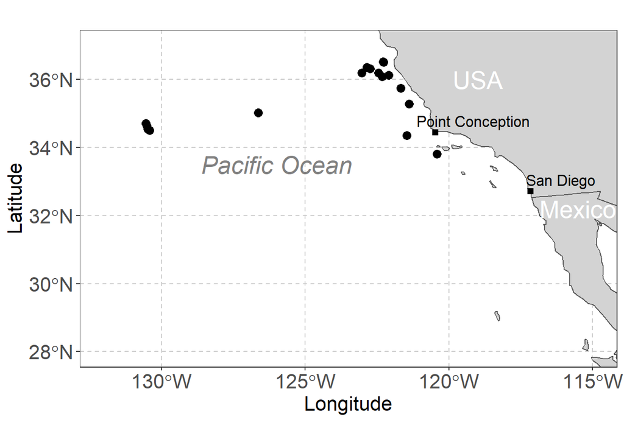

```r
# Sampling locations with ggplot2 and sf

theme_set(theme_bw())
world <- ne_countries(scale='medium', returnclass = 'sf')

# Mapping the stations in the CCE

lonmin = -132
lonmax = -115
latmin = 28
latmax = 37

sites <- st_as_sf(data.frame(name = c("Point Conception", "San Diego"),
                             longitude = c(-120.470833,-117.1625),
                             latitude = c(34.448889,32.715)),
                  coords = c("longitude", "latitude"), remove=FALSE,
                  crs = 4326, agr = "constant")

samp_loc <- st_as_sf(sampling_loc,
                     coords = c("Longitude", "Latitude"), remove=FALSE,
                     crs = 4326, agr = "constant")

map_cce <- ggplot(data = world) +
  geom_sf(fill = "lightgray") +
  theme(axis.title.x = element_text(size = 16),
        axis.text.x = element_text(size = 16),
        axis.title.y = element_text(size = 16),
        axis.text.y = element_text(size = 16)) +
  scale_shape_discrete(solid=F) +
  geom_sf(data = samp_loc, size = 3, show.legend=T) +
  theme(legend.position = c(1, 1), legend.justification = c(1, 1),
        legend.background = element_rect(fill = "white", colour = "black"),
        legend.title = element_text(size=16),
        legend.text = element_text(size=16)) +
  geom_sf(data = sites, size = 2, shape = 15) +
  geom_text_repel(data = sites,
                  aes(x = longitude, y = latitude, label = name),
                  size = 4.4, nudge_x = c(1.25, 1), nudge_y = c(0.3, 0.3),
                  min.segment.length = 2) +
  annotate(geom = "text", x = -119, y = 36, label = "USA",
           color = "white", size = 7) +
  annotate(geom = "text", x = -115.5, y = 32.2, label = "Mexico",
           color = "white", size = 7) +
  annotate(geom = "text", x = -126, y = 33.5, label = "Pacific Ocean",
           color = grey(0.5), size = 7, fontface = "italic") +
  coord_sf(xlim = c(lonmin, lonmax), ylim = c(latmin, latmax)) +
  xlab("Longitude")+ ylab("Latitude")+
  theme(panel.grid.major = element_line(colour = gray(0.8), linetype = "dashed",
                                        size = 0.5),
        panel.background = element_rect(fill = "white"),
        panel.border = element_rect(fill = NA))

map_cce
```

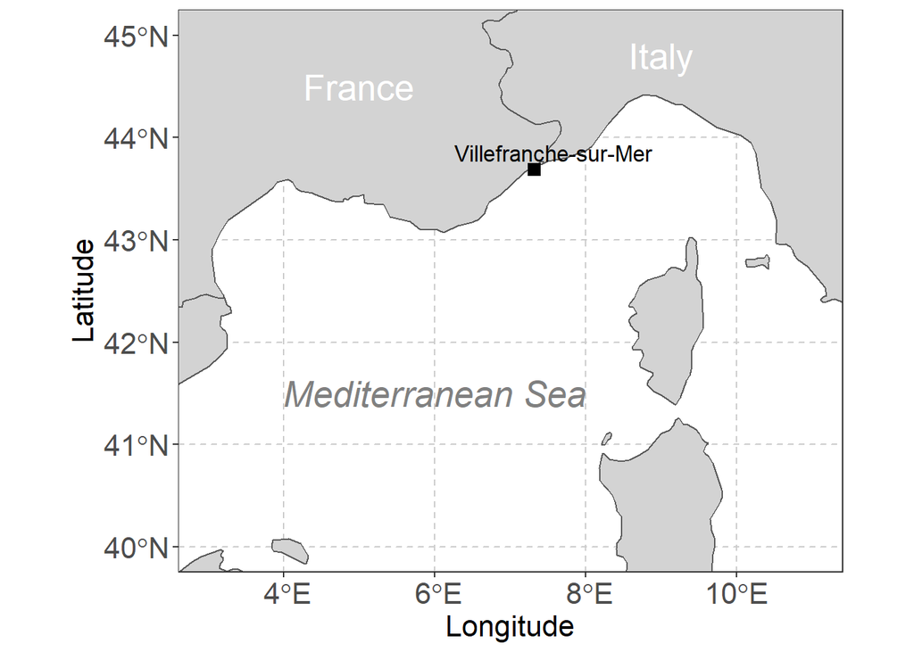

```r
# Mapping Point B in Villefranche/Mer Bay

lonmin <- 3
lonmax <- 11
latmin <- 45
latmax <- 40

villefranche <- data.frame(x = 7.3139, y = 43.6861,
                           label = "Villefranche-sur-Mer")

map_med <- ggplot(data = world) +
  geom_sf(fill = "lightgray") +
  theme(axis.title.x = element_text(size = 16),
        axis.text.x = element_text(size = 16),
        axis.title.y = element_text(size = 16),
        axis.text.y = element_text(size = 16)) +
  scale_shape_discrete(solid=F) +
  geom_point(data = villefranche, aes(x = x, y = y), size = 3, shape = 15) +
  geom_text_repel(data = villefranche,
                  aes(x = x, y = y, label = label),
                  size = 4.4, min.segment.length = 2) +
  theme(legend.position = c(1, 1), legend.justification = c(1, 1),
        legend.background = element_rect(fill = "white", colour = "black"),
        legend.title = element_text(size=16),
        legend.text = element_text(size=16)) +
  annotate(geom = "text", x = 5, y = 44.5, label = "France",
           color = "white", size = 7) +
  annotate(geom = "text", x = 9, y = 44.8, label = "Italy",
           color = "white", size = 7) +
  annotate(geom = "text", x = 6, y = 41.5, label = "Mediterranean Sea",
           color = grey(0.5), size = 7, fontface = "italic") +
  coord_sf(xlim = c(lonmin, lonmax), ylim = c(latmin, latmax)) +
  xlab("Longitude") + ylab("Latitude") +
  theme(panel.grid.major = element_line(colour = gray(0.8), linetype = "dashed",
                                        size = 0.5),
        panel.background = element_rect(fill = "white"),
        panel.border = element_rect(fill = NA))

map_med
```

```r
# Saving maps in the results/ folder

ggsave2("results/sampling_locations_cce_2021.png", plot = map_cce)
ggsave2("results/sampling_locations_med_2019.png", plot = map_med)
```

## Carbon and nitrogen content of planktonic Rhizaria Rhizaria

### Loading and cleaning elemental data

Data come from this study and Mansour et al. (2021).

```r
data <- readxl::read_xlsx("data/data_CN.xlsx")

# Removing data deemed as outliers
data <- data %>% filter(is.na(to_remove))

# Elemental data are converted in µg/cell
# and volume data in mm3
# Colonial Collodaria are considered as single individuals
data <- data %>%
  mutate(ugC_per_ind = case_when(
  mode=="colonial" ~ total_C_ug,
  mode=="solitary" ~ ngC_per_cell*(10^(-3))
  )) %>%
  mutate(ugN_per_ind = case_when(
  mode=="colonial" ~ total_N_ug,
  mode=="solitary" ~ ngN_per_cell*(10^(-3))
  )) %>%
  mutate(individual_volume = case_when(
    mode=="colonial" ~ colony_volume_mm3,
    mode=="solitary" ~ cell_vol_mean*(10^(-9))
  )) %>%
  mutate(ugC_per_mm3 = ugC_per_ind/individual_volume) %>%
  mutate(ugN_per_mm3 = ugN_per_ind/individual_volume)
```

### Data summary

```r
# Counting samples and cells by reference
counts_ref <- data %>% #filter(reference=="This study") %>%
  summarise(n_samples_C = sum(!is.na(ugC_per_ind)),
            n_cells_C = sum((!is.na(ugC_per_ind))*n_cells),
            n_samples_N = sum(!is.na(ugN_per_ind)),
            n_cells_N = sum((!is.na(ugN_per_ind))*n_cells))
print(counts_ref)
```

```
##   n_samples_C n_cells_C n_samples_N n_cells_N
## 1         274  59887.02         235  57214.29
```

Getting minimum and maximum values for C and N contents for this study:

```r
#Carbon
ccont <- data %>% filter(reference=="This study") %>%
  group_by(type) %>%
  filter(type!="Cytocladus") %>%
  summarise(mean_C = mean(na.omit(ugC_per_ind)),
            sd_C = sd(na.omit(ugC_per_ind)))
minC <- ccont[which.min(ccont$mean_C),]
maxC <- ccont[which.max(ccont$mean_C),]
print(minC)
```

```
##     mean_C     sd_C
## 1 14.67232 23.02194
```

```r
print(maxC)
```

```
##     mean_C     sd_C
## 1 14.67232 23.02194
```

```r
# Nitrogen
ncont <- data %>% filter(reference=="This study") %>%
  group_by(type) %>%
  filter(type!="Cytocladus") %>%
  summarise(mean_N = mean(na.omit(ugN_per_ind)),
            sd_N = sd(na.omit(ugN_per_ind)))
minN <- ncont[which.min(ncont$mean_N),]
maxN <- ncont[which.max(ncont$mean_N),]
print(minN)
```

```
##     mean_N     sd_N
## 1 3.041948 5.675149
```

```r
print(maxN)
```

```
##     mean_N     sd_N
## 1 3.041948 5.675149
```

Summary of C:N ratios:

```r
# Getting mean, max and min C:N ratio for this study

mean_cn <- data %>% filter(reference=="This study") %>%
  summarise(mean_cn = mean(na.omit(c_n_ratio)),
            sd_cn = sd(na.omit(c_n_ratio)))
print(mean_cn)
```

```
##    mean_cn    sd_cn
## 1 7.772381 2.071374
```

```r
ratio <- data %>% filter(reference=="This study") %>%
  group_by(type) %>%
  summarise(mean_ratio = mean(na.omit(c_n_ratio)),
            sd_ratio = sd(na.omit(c_n_ratio)))
minratio <- ratio[which.min(ratio$mean_ratio),]
maxratio <- ratio[which.max(ratio$sd_ratio),]
print(minratio)
```

```
##   mean_ratio sd_ratio
## 1   7.772381 2.071374
```

```r
print(maxratio)
```

```
##   mean_ratio sd_ratio
## 1   7.772381 2.071374
```

### Table 1: C & N contents data summary

```r
# Summarizing the dataset
table <- data %>%
  dplyr::select(group, order, type, n_cells, cell_vol_mean, cell_vol_sd,
                esd_mean, esd_sd, ugC_per_ind, ugC_per_mm3,
                ugN_per_ind, ugN_per_mm3, c_n_ratio, reference)  %>%
  group_by(group, order, type, reference) %>%
  dplyr::summarise(group = unique(group),
            order = unique(order),
            # ESD
            Mean_esd = as.integer(mean(na.omit(esd_mean))),
            SD_esd = as.integer(sd(na.omit(esd_mean))),
            # Carbon
            n_samples_C = sum(!is.na(ugC_per_ind)),
            n_cells_C = as.integer(sum((!is.na(ugC_per_ind))*n_cells)),
            Mean_carbon_content = mean(na.omit(ugC_per_ind)),
            SD_carbon_content = sd(na.omit(ugC_per_ind)),
            Mean_carbon_density = mean(na.omit(ugC_per_mm3)),
            SD_carbon_density = sd(na.omit(ugC_per_mm3)),
            # Nitrogen
            n_samples_N = sum(!is.na(ugN_per_ind)),
            n_cells_N = as.integer(sum((!is.na(ugN_per_ind))*n_cells)),
            Mean_nitrogen_content = mean(na.omit(ugN_per_ind)),
            SD_nitrogen_content = sd(na.omit(ugN_per_ind)),
            Mean_nitrogen_density = mean(na.omit(ugN_per_mm3)),
            SD_nitrogen_density = sd(na.omit(ugN_per_mm3)),
            #C:N ratio
            Mean_cn_ratio = mean(na.omit(c_n_ratio)),
            sd_cn_ratio = sd(na.omit(c_n_ratio))
            )

# Creating the table
table %>%
  dplyr::select(-reference, reference) %>%
  dplyr::rename('Reference' = reference,
         'Group' = group,
         'Taxon' = type
         ) %>%
  kable("html",
        caption = "Summary of carbon and nitrogen contents data used for this
        analysis, compiled from Mansour et al. (2021) and this study.",
        digits = 1) %>%
  collapse_rows(.) %>%
  kable_styling("striped", full_width = F, position="left")
```

Summary of carbon and nitrogen contents data used for this analysis, compiled from Mansour et al. (2021) and this study.

| Group | order | Taxon | Mean_esd | SD_esd | n_samples_C | n_cells_C | Mean_carbon_content | SD_carbon_content | Mean_carbon_density | SD_carbon_density | n_samples_N | n_cells_N | Mean_nitrogen_content | SD_nitrogen_content | Mean_nitrogen_density | SD_nitrogen_density | Mean_cn_ratio | sd_cn_ratio | Reference |
| --- | --- | --- | --- | --- | --- | --- | --- | --- | --- | --- | --- | --- | --- | --- | --- | --- | --- | --- | --- |
| Phaeodaria | Aulacanthida | Aulacanthidae CCE | 909 | 671 | 34 | 596 | 5.8 | 10.0 | 11.2 | 8.8 | 23 | 540 | 1.2 | 2.0 | 1.4 | 0.6 | 7.0 | 0.6 | This study |
| Phaeodaria | Aulacanthida | Aulacanthidae Med. | 733 | 124 | 17 | 302 | 3.1 | 1.6 | 18.0 | 15.3 | 17 | 302 | 0.3 | 0.2 | 1.8 | 1.6 | 12.4 | 2.3 | Mansour et al., 2021 |
| Phaeodaria | Phaeocalpida | Castanellidae | 632 | 89 | 35 | 567 | 7.4 | 2.6 | 52.9 | 13.1 | 34 | 566 | 1.1 | 0.4 | 8.0 | 2.1 | 7.7 | 0.7 | This study |
| Phaeodaria | Phaeocalpida | Tuscaroridae | 1210 | 93 | 7 | 10 | 45.3 | 23.1 | 48.9 | 25.1 | 7 | 10 | 7.5 | 4.0 | 8.0 | 3.9 | 7.1 | 0.5 | This study |
| Phaeodaria | Phaeodendrida | Coelodendridae | 1609 | 695 | 13 | 45 | 12.5 | 10.1 | 4.9 | 2.1 | 9 | 26 | 2.6 | 1.3 | 0.8 | 0.3 | 7.8 | 0.8 | This study |
| Phaeodaria | Phaeogromida | Challengeria | 184 | 73 | 2 | 48 | 1.2 | 1.4 | 241.2 | 108.8 | 2 | 48 | 0.1 | 0.1 | 14.6 | 1.7 | 19.0 | 6.6 | Mansour et al., 2021 |
| Phaeodaria | Phaeogromida | Medusettidae | 1893 | 456 | 3 | 4 | 23.8 | 12.5 | 7.4 | 4.1 | 3 | 4 | 4.1 | 1.8 | 1.3 | 0.7 | 6.7 | 0.6 | This study |
| Phaeodaria | Phaeogromida | Protocystis CCE | 318 | 53 | 11 | 213 | 0.7 | 0.4 | 39.7 | 13.0 | 10 | 200 | 0.1 | 0.1 | 6.1 | 2.7 | 7.9 | 2.0 | This study |
| Phaeodaria | Phaeogromida | Protocystis SO | 97 | 8 | 12 | 414 | 0.7 | 0.5 | 2224.4 | 1283.2 | 12 | 414 | 0.1 | 0.0 | 259.3 | 131.4 | 10.0 | 2.1 | Mansour et al., 2021 |
| Phaeodaria | Phaeosphaerida | Aulosphaeridae | 1959 | 206 | 10 | 120 | 2.3 | 0.7 | 0.6 | 0.2 | 10 | 120 | 0.4 | 0.1 | 0.1 | 0.0 | 6.5 | 0.8 | This study |
| Radiolaria | Acantharia | Acantharia |  |  | 18 | 540 | 0.2 | 0.2 |  |  | 0 | 0 |  |  |  |  |  |  | Mansour et al., 2021 |
| Radiolaria | Collodaria | Collodaria (Collosphaeridae) | 94 | 29 | 8 | 15033 | 80.7 | 41.2 | 0.6 | 0.4 | 6 | 14589 | 17.0 | 4.5 | 0.1 | 0.1 | 7.4 | 2.0 | Mansour et al., 2021 |
| Radiolaria | Collodaria | Collodaria (sol.) | 286 | 404 | 2 | 32 | 21.6 | 0.0 | 155.1 | 47.7 | 2 | 32 | 3.7 | 0.0 | 26.8 | 8.2 | 6.8 | 0.0 | Mansour et al., 2021 |
| Radiolaria | Collodaria | Collodaria (sol.) | 3425 | 558 | 13 | 33 | 65.1 | 32.8 | 3.1 | 1.9 | 13 | 33 | 15.4 | 10.4 | 0.7 | 0.5 | 5.7 | 1.4 | This study |
| Radiolaria | Collodaria | Collodaria (Sphaerozoidae) | 116 | 25 | 54 | 41111 | 99.8 | 87.5 | 1.9 | 1.7 | 52 | 39511 | 13.7 | 8.2 | 0.4 | 0.4 | 7.6 | 3.1 | Mansour et al., 2021 |
| Radiolaria | Nassellaria | Nassellaria (other) | 83 | 6 | 6 | 241 | 0.5 | 0.2 | 1472.1 | 729.7 | 6 | 241 | 0.1 | 0.0 | 171.3 | 85.3 | 10.3 | 1.7 | Mansour et al., 2021 |
| Radiolaria | Nassellaria | Nassellaria (Phlebarachnium) | 1175 | 289 | 19 | 468 | 6.4 | 1.6 | 8.9 | 5.1 | 19 | 468 | 0.7 | 0.3 | 0.9 | 0.3 | 11.3 | 2.8 | This study |
| Radiolaria | Orodaria | Cytocladus | 9719 |  | 1 | 1 | 717.6 |  | 1.5 |  | 1 | 1 | 76.8 |  | 0.2 |  | 10.9 |  | This study |
| Radiolaria | Orodaria | Oroscena | 1492 | 571 | 5 | 8 | 44.3 | 34.0 | 25.0 | 14.1 | 5 | 8 | 7.2 | 5.3 | 4.1 | 2.4 | 7.2 | 0.8 | This study |
| Radiolaria | Spumellaria | Spumellaria | 157 | 38 | 2 | 74 | 0.8 | 0.3 | 328.1 | 126.9 | 2 | 74 | 0.1 | 0.0 | 45.6 | 32.5 | 9.7 | 3.7 | Mansour et al., 2021 |
| Radiolaria | Spumellaria | Spumellaria | 220 | 60 | 2 | 26 | 1.5 | 0.6 | 279.7 | 104.8 | 2 | 26 | 0.3 | 0.1 | 45.1 | 14.4 | 7.2 | 0.4 | This study |

### Volume to carbon content relationship

Let’s fit the linear model on the log10-transformed data:

```r
# Fitting a linear model (OLS) for all individuals with LOOCV

train_control <- trainControl(method = "LOOCV")

model <- data %>% dplyr::select(ugC_per_ind, individual_volume) %>%
  filter(!is.na(individual_volume)) %>%
  filter(!is.na(ugC_per_ind)) %>%
  mutate(ugC_per_ind = log10(ugC_per_ind),
         individual_volume = log10(individual_volume)) %>%
  train(ugC_per_ind ~., data = ., method = "lm",
        trControl = train_control)

summary(model)
```

```
##
## Call:
## lm(formula = .outcome ~ ., data = dat)
##
## Residuals:
##      Min       1Q   Median       3Q      Max
## -1.09159 -0.26709  0.03806  0.29047  0.90862
##
## Coefficients:
##                   Estimate Std. Error t value Pr(>|t|)
## (Intercept)        0.95774    0.02474   38.72   <2e-16 ***
## individual_volume  0.45526    0.01603   28.40   <2e-16 ***
## ---
## Signif. codes:  0 '***' 0.001 '**' 0.01 '*' 0.05 '.' 0.1 ' ' 1
##
## Residual standard error: 0.3948 on 254 degrees of freedom
## Multiple R-squared:  0.7606, Adjusted R-squared:  0.7596
## F-statistic: 806.8 on 1 and 254 DF,  p-value: < 2.2e-16
```

Analysis of residuals:

```r
resid <- tibble(.rows = 256)
resid$fitted_values <- model$finalModel$fitted.values
resid$residuals <- model$finalModel$residuals

# Fitted values vs residuals
p1 <- ggplot(resid, aes(x = fitted_values, y = residuals)) +
  geom_point() +
  geom_hline(yintercept=0) +
  theme_bw() +
  theme(text = element_text(size = 16), element_line(size = 0.4)) +
  xlab("Fitted values") +
  ylab("Residuals")

# Theoretical quantiles vs observed quantiles
p2 <- ggplot(resid, aes(sample=residuals)) +
  stat_qq() +
  stat_qq_line() +
  theme_bw() +
  theme(text = element_text(size = 16), element_line(size = 0.4)) +
  xlab("Theoretical quantiles") +
  ylab("Sample quantiles")

# Density of residuals
p3 <- ggplot(resid, aes(x=residuals)) +
  geom_density() +
  theme_bw() +
  theme(text = element_text(size = 16), element_line(size = 0.4)) +
  xlab("Residuals") +
  ylab("Density")

# Saving the 3 plots
ggsave2("results/resid1_carbon.pdf", p1)
ggsave2("results/resid2_carbon.pdf", p2)
ggsave2("results/resid3_carbon.pdf", p3)
```

Let’s calculate the prediction intervals at 95% for this C:V relationship.

```r
# Create a vector covering the whole size spectrum
newx <- data.frame(individual_volume = model$finalModel$model$individual_volume)

# Predict with model
ypredC <- predict(model$finalModel, newdata = newx,
                  interval = "predict", level = 0.95)
ypredC <- as.data.frame(ypredC)
ypredC$x <- 10^(newx$individual_volume)
ypredC$fit <- 10^ypredC$fit
ypredC$lwr <- 10^ypredC$lwr
ypredC$upr <- 10^ypredC$upr
```

### Volume to nitrogen content

We’ll just do the same for nitrogen. First we fit the model:

```r
# Fitting a linear model (OLS) for all individuals with LOOCV

model <- data %>% dplyr::select(ugN_per_ind, individual_volume) %>%
  filter(!is.na(individual_volume)) %>%
  filter(!is.na(ugN_per_ind)) %>%
  mutate(ugN_per_ind = log10(ugN_per_ind),
         individual_volume = log10(individual_volume)) %>%
  train(ugN_per_ind ~., data = ., method = "lm",
        trControl = train_control)

summary(model)
```

```
##
## Call:
## lm(formula = .outcome ~ ., data = dat)
##
## Residuals:
##      Min       1Q   Median       3Q      Max
## -1.23184 -0.27868  0.05891  0.28170  0.91927
##
## Coefficients:
##                   Estimate Std. Error t value Pr(>|t|)
## (Intercept)        0.15738    0.02643   5.954 9.57e-09 ***
## individual_volume  0.47663    0.01675  28.453  < 2e-16 ***
## ---
## Signif. codes:  0 '***' 0.001 '**' 0.01 '*' 0.05 '.' 0.1 ' ' 1
##
## Residual standard error: 0.4046 on 233 degrees of freedom
## Multiple R-squared:  0.7765, Adjusted R-squared:  0.7756
## F-statistic: 809.6 on 1 and 233 DF,  p-value: < 2.2e-16
```

Analysis of residuals:

```r
resid <- tibble(.rows = 235)
resid$fitted_values <- model$finalModel$fitted.values
resid$residuals <- model$finalModel$residuals

# Fitted values vs residuals
p1 <- ggplot(resid, aes(x = fitted_values, y = residuals)) +
  geom_point() +
  geom_hline(yintercept=0) +
  theme_bw() +
  theme(text = element_text(size = 16), element_line(size = 0.4)) +
  xlab("Fitted values") +
  ylab("Residuals")

# Theoretical quantiles vs observed quantiles
p2 <- ggplot(resid, aes(sample=residuals)) +
  stat_qq() +
  stat_qq_line() +
  theme_bw() +
  theme(text = element_text(size = 16), element_line(size = 0.4)) +
  xlab("Theoretical quantiles") +
  ylab("Sample quantiles")

# Density of residuals
p3 <- ggplot(resid, aes(x=residuals)) +
  geom_density() +
  theme_bw() +
  theme(text = element_text(size = 16), element_line(size = 0.4)) +
  xlab("Residuals") +
  ylab("Density")

# Saving the 3 plots
ggsave2("results/resid1_nitrogen.pdf", p1)
ggsave2("results/resid2_nitrogen.pdf", p2)
ggsave2("results/resid3_nitrogen.pdf", p3)
```

Again calculate the prediction intervals at 95% for this N:V relationship.

```r
# Create a vector covering the whole size spectrum
newx <- data.frame(individual_volume = model$finalModel$model$individual_volume)

# Predict with model
ypredN <- predict(model$finalModel, newdata = newx,
                  interval = "predict", level = 0.95)
ypredN <- as.data.frame(ypredN)
ypredN$x <- 10^(newx$individual_volume)
ypredN$fit <- 10^ypredN$fit
ypredN$lwr <- 10^ypredN$lwr
ypredN$upr <- 10^ypredN$upr
```

### Comparison with other protists

| Group | Allometric relationship | Reference |
| --- | --- | --- |
| Protists excluding diatoms* | $C = 0.216 \times V^{0.939}$ | Menden-Deuer and Lessard (2000) |
| Diatoms | $C = 0.288 \times V^{0.811}$ | Menden-Deuer and Lessard (2000) |
| Rhizaria | $C = 9.078 \times V^{0.455}$ | This study |

```r
# Testing for differences with Menden-Deuer and Lessard (2000)

# Regression slopes
slope_protists = 0.939
slope_diatoms = 0.811

coefs <- coef(summary(model))

t_protists = (coefs[2,1] - slope_protists)/coefs[2,2]
t_diatoms = (coefs[2,1] - slope_diatoms)/coefs[2,2]

# Getting p-values

# Various protists
pt(t_protists, model$finalModel$df.residual)
```

```
## [1] 1.078821e-75
```

```r
# Diatoms
pt(t_diatoms, model$finalModel$df.residual)
```

```
## [1] 1.19126e-52
```

### Plotting regressions

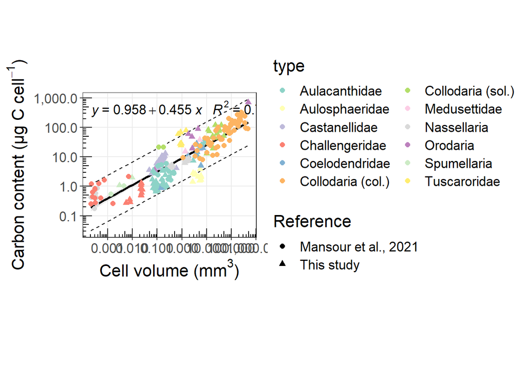

```r
# Plotting regression

reg_carbon <- data %>%
  # Removing Acantharia for which no size data
  filter(type!="Acantharia") %>%
  # Renaming taxa
  mutate(type = case_when(
    type=="Aulacanthidae CCE" ~ "Aulacanthidae",
    type=="Aulacanthidae Med." ~ "Aulacanthidae",
    type=="Protocystis SO" ~ "Challengeridae",
    type=="Protocystis CCE" ~ "Challengeridae",
    type=="Challengeria" ~ "Challengeridae",
    type=="Nassellaria (other)" ~ "Nassellaria",
    type=="Nassellaria (Phlebarachnium)" ~ "Nassellaria",
    type=="Oroscena" ~ "Orodaria",
    type=="Cytocladus" ~ "Orodaria",
    type=="Collodaria (Sphaerozoidae)" ~ "Collodaria (col.)",
    type=="Collodaria (Collosphaeridae)" ~ "Collodaria (col.)",
    TRUE ~ type
  )) %>%
  ggplot(., aes(x=individual_volume, y=ugC_per_ind)) +
  geom_smooth(method = "lm", col = "black", fill = "lightgrey") +
  # Adding prediction intervals
  geom_line(data = ypredC, inherit.aes = FALSE,
            aes(x = x, y = lwr),
            col = "black", linetype = "dashed", alpha = 0.9) +
  geom_line(data = ypredC, inherit.aes = FALSE,
            aes(x = x, y = upr),
            col = "black", linetype = "dashed", alpha = 0.9) +
  # Plot points
  geom_point(aes(color = type, shape = reference),
             size = 2) +
  # Log scale
  scale_y_log10(breaks = 10^seq(-3,5), minor_breaks = NULL, labels = comma) +
  scale_x_log10(breaks = 10^seq(-3,5), minor_breaks = NULL, labels = comma) +
  annotation_logticks(sides="bl") +
  # Adding equation
  stat_poly_eq(formula = y~x,
               aes(label = paste(..eq.label.., ..rr.label.., sep = "~~~"),
                   size = 28),
               parse = TRUE, coef.digits = 3, f.digits = 3, p.digits = 5) +
  # Nice aesthetics
  theme_bw() +
  theme(text = element_text(size = 16), element_line(size = 0.4),
        aspect.ratio = 10/12) +
  #scale_color_carto_d(name = "Group", palette = "Safe") +
  scale_color_brewer(palette = "Set3") +
  scale_shape_discrete(name = "Reference") +
  guides(alpha = "none", color = guide_legend(ncol=2)) +
  # Axes
  xlab(TeX("Cell volume ($mm ^3$)")) +
  ylab(TeX("Carbon content (µg C cell$^{-1}$)"))

reg_carbon
```

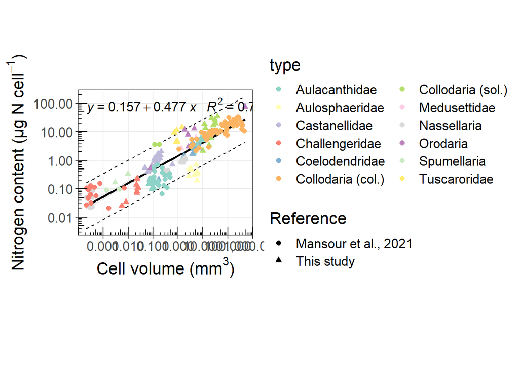

```r
reg_nitrogen <- data %>%
  # Removing Acantharia for which no size data
  filter(type!="Acantharia") %>%
  # Renaming taxa
  mutate(type = case_when(
    type=="Aulacanthidae CCE" ~ "Aulacanthidae",
    type=="Aulacanthidae Med." ~ "Aulacanthidae",
    type=="Protocystis SO" ~ "Challengeridae",
    type=="Protocystis CCE" ~ "Challengeridae",
    type=="Challengeria" ~ "Challengeridae",
    type=="Nassellaria (other)" ~ "Nassellaria",
    type=="Nassellaria (Phlebarachnium)" ~ "Nassellaria",
    type=="Oroscena" ~ "Orodaria",
    type=="Cytocladus" ~ "Orodaria",
    type=="Collodaria (Sphaerozoidae)" ~ "Collodaria (col.)",
    type=="Collodaria (Collosphaeridae)" ~ "Collodaria (col.)",
    TRUE ~ type
  )) %>%
  ggplot(., aes(x=individual_volume, y=ugN_per_ind)) +
  geom_smooth(method = "lm", col = "black", fill = "lightgrey") +
    # Adding prediction intervals
  geom_line(data = ypredN, inherit.aes = FALSE,
            aes(x = x, y = lwr),
            col = "black", linetype = "dashed", alpha = 0.9) +
  geom_line(data = ypredN, inherit.aes = FALSE,
            aes(x = x, y = upr),
            col = "black", linetype = "dashed", alpha = 0.9) +
  # Plot points
  geom_point(aes(color = type, shape = reference),
             size = 2) +
  # Log scale
  scale_y_log10(breaks = 10^seq(-3,5), minor_breaks = NULL, labels = comma) +
  scale_x_log10(breaks = 10^seq(-3,5), minor_breaks = NULL, labels = comma) +
  annotation_logticks(sides="bl") +
  # Adding equation
  stat_poly_eq(formula = y~x,
               aes(label = paste(..eq.label.., ..rr.label.., sep = "~~~"),
                   size = 28),
               parse = TRUE, coef.digits = 3, f.digits = 3, p.digits = 5) +
  # Nice aesthetics
  theme_bw() +
  theme(text = element_text(size = 16), element_line(size = 0.4),
        aspect.ratio = 10/12) +
  #scale_color_carto_d(name = "Group", palette = "Safe") +
  scale_color_brewer(palette = "Set3") +
  scale_shape_discrete(name = "Reference") +
  guides(alpha = "none", color = guide_legend(ncol=2)) +
  # Axes
  xlab(TeX("Cell volume ($mm ^3$)")) +
  ylab(TeX("Nitrogen content (µg N cell$^{-1}$)"))

reg_nitrogen
```

```r
# Getting common legend

# Get tabular interpretation of plot
plot_table <- ggplot_gtable(ggplot_build(reg_carbon))
# Mark only legend in plot
legend_plot <- which(sapply(plot_table$grobs, function(x) x$name) == "guide-box")
# extract legend
legend <- plot_table$grobs[[legend_plot]]

reg_carbon <- reg_carbon + theme(legend.position = "none")
reg_nitrogen <- reg_nitrogen + theme(legend.position = "none")

ggsave2("results/loglog_vol_carbon.pdf", reg_carbon)
ggsave2("results/loglog_vol_nitrogen.pdf", reg_nitrogen)
ggsave2("results/loglog_vol_elemental_legend.pdf", legend)
```

### Plotting regressions for diapo

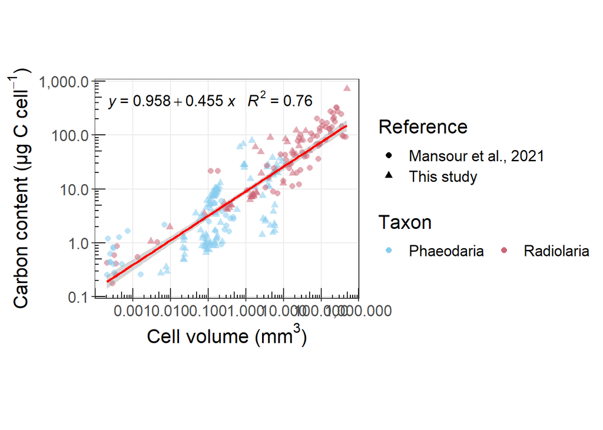

```r
# Plotting regression

reg_carbon <- data %>%
  filter(type!="Acantharia") %>%
  mutate(type = case_when(
    type=="Aulacanthidae CCE" ~ "Aulacanthidae",
    type=="Aulacanthidae Med." ~ "Aulacanthidae",
    type=="Protocystis SO" ~ "Challengeridae",
    type=="Protocystis CCE" ~ "Challengeridae",
    type=="Challengeria" ~ "Challengeridae",
    type=="Nassellaria (other)" ~ "Nassellaria",
    type=="Nassellaria (Phlebarachnium)" ~ "Nassellaria",
    type=="Oroscena" ~ "Orodaria",
    type=="Cytocladus" ~ "Orodaria",
    type=="Collodaria (Sphaerozoidae)" ~ "Collodaria (col.)",
    type=="Collodaria (Collosphaeridae)" ~ "Collodaria (col.)",
    TRUE ~ type
  )) %>%
  ggplot(., aes(x=individual_volume, y=ugC_per_ind)) +
  geom_point(aes(color = group, shape = reference, alpha =  0.95),
             size = 2) +
  scale_y_log10(breaks = 10^seq(-3,5), minor_breaks = NULL, labels = comma) +
  scale_x_log10(breaks = 10^seq(-3,5), minor_breaks = NULL, labels = comma) +
  annotation_logticks(sides="bl") +
  geom_smooth(method = "lm", col = "red") +
  stat_poly_eq(formula = y~x,
               aes(label = paste(..eq.label.., ..rr.label.., sep = "~~~"),
                   size = 28),
               parse = TRUE, coef.digits = 3, f.digits = 3, p.digits = 5) +
  theme_bw() +
  theme(text = element_text(size = 16), element_line(size = 0.4),
        aspect.ratio = 10/12) +
  scale_color_carto_d(name = "Taxon", palette = "Safe") +
  scale_shape_discrete(name = "Reference") +
  guides(alpha = "none", color = guide_legend(ncol=2)) +
  xlab(TeX("Cell volume ($mm ^3$)")) +
  ylab(TeX("Carbon content (µg C cell$^{-1}$)"))

reg_carbon
```

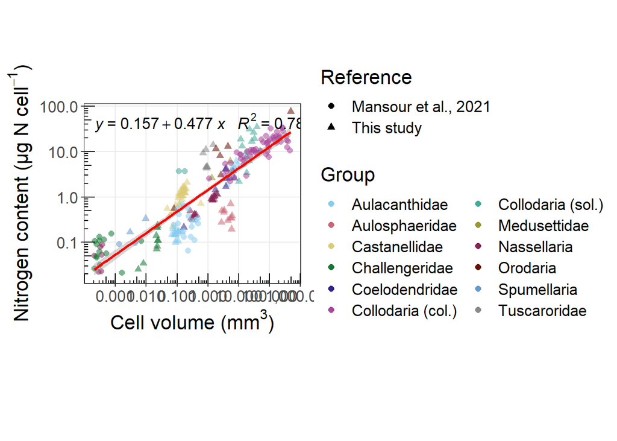

```r
reg_nitrogen <- data %>%
  filter(type!="Acantharia") %>%
  mutate(type = case_when(
    type=="Aulacanthidae CCE" ~ "Aulacanthidae",
    type=="Aulacanthidae Med." ~ "Aulacanthidae",
    type=="Protocystis SO" ~ "Challengeridae",
    type=="Protocystis CCE" ~ "Challengeridae",
    type=="Challengeria" ~ "Challengeridae",
    type=="Nassellaria (other)" ~ "Nassellaria",
    type=="Nassellaria (Phlebarachnium)" ~ "Nassellaria",
    type=="Oroscena" ~ "Orodaria",
    type=="Cytocladus" ~ "Orodaria",
    type=="Collodaria (Sphaerozoidae)" ~ "Collodaria (col.)",
    type=="Collodaria (Collosphaeridae)" ~ "Collodaria (col.)",
    TRUE ~ type
  )) %>%
  ggplot(., aes(x=individual_volume, y=ugN_per_ind)) +
  geom_point(aes(color = type, shape = reference, alpha =  0.95),
             size = 2) +
  scale_y_log10(breaks = 10^seq(-3,5), minor_breaks = NULL, labels = comma) +
  scale_x_log10(breaks = 10^seq(-3,5), minor_breaks = NULL, labels = comma) +
  annotation_logticks(sides="bl") +
  geom_smooth(method = "lm", col = "red") +
  stat_poly_eq(formula = y~x,
               aes(label = paste(..eq.label.., ..rr.label.., sep = "~~~"),
                   size = 28),
               parse = TRUE, coef.digits = 3, f.digits = 3, p.digits = 5) +
  theme_bw() +
  theme(text = element_text(size = 16), element_line(size = 0.4),
        aspect.ratio = 10/12) +
  scale_color_carto_d(name = "Group", palette = "Safe") +
  scale_shape_discrete(name = "Reference") +
  guides(alpha = "none", color = guide_legend(ncol=2)) +
  xlab(TeX("Cell volume ($mm ^3$)")) +
  ylab(TeX("Nitrogen content (µg N cell$^{-1}$)"))

reg_nitrogen
```

```r
# Getting common legend

# Get tabular interpretation of plot
plot_table <- ggplot_gtable(ggplot_build(reg_carbon))
# Mark only legend in plot
legend_plot <- which(sapply(plot_table$grobs, function(x) x$name) == "guide-box")
# extract legend
legend <- plot_table$grobs[[legend_plot]]

reg_carbon <- reg_carbon + theme(legend.position = "none")
reg_nitrogen <- reg_nitrogen + theme(legend.position = "none")

ggsave2("results/diapo_loglog_vol_carbon.png", reg_carbon)
ggsave2("results/diapo_loglog_vol_nitrogen.png", reg_nitrogen)
ggsave2("results/diapo_loglog_vol_elemental_legend.png", legend)
```

### Separate models for Radiolaria and Phaeodaria

```r
# Comparing models with or without interaction using ANOVA

# Carbon
mod1_c <- lm(ugC_per_ind ~ individual_volume, data = data)
mod2_c <- lm(ugC_per_ind ~ individual_volume*group, data = data)
anova(mod1_c, mod2_c)
```

```
## Analysis of Variance Table
##
## Model 1: ugC_per_ind ~ individual_volume
## Model 2: ugC_per_ind ~ individual_volume * group
##   Res.Df    RSS Df Sum of Sq      F   Pr(>F)
## 1    254 465367
## 2    252 446573  2     18794 5.3027 0.005549 **
## ---
## Signif. codes:  0 '***' 0.001 '**' 0.01 '*' 0.05 '.' 0.1 ' ' 1
```

```r
# Nitrogen
mod1_n <- lm(ugN_per_ind ~ individual_volume, data = data)
mod2_n <- lm(ugN_per_ind ~ individual_volume*group, data = data)
anova(mod1_n, mod2_n)
```

```
## Analysis of Variance Table
##
## Model 1: ugN_per_ind ~ individual_volume
## Model 2: ugN_per_ind ~ individual_volume * group
##   Res.Df    RSS Df Sum of Sq      F    Pr(>F)
## 1    233 8858.6
## 2    231 7769.3  2    1089.3 16.194 2.621e-07 ***
## ---
## Signif. codes:  0 '***' 0.001 '**' 0.01 '*' 0.05 '.' 0.1 ' ' 1
```

```r
# Carbon content

model.reg.c <- function(data, group_name) {

  # Defining training control as Leave One Out Cross Validation
  train_control <- trainControl(method = "LOOCV")

  # Training the model by assigning log 10 carbon content per cell column
  # as dependant variable and log 10 cell volume as independent variable
  model <- data %>% filter(group==group_name) %>%
    dplyr::select(ugC_per_ind, individual_volume) %>%
    filter(!is.na(individual_volume)) %>%
    filter(!is.na(ugC_per_ind)) %>%
    mutate(ugC_per_ind = log10(ugC_per_ind),
           individual_volume = log10(individual_volume)) %>%
    train(ugC_per_ind ~., data = ., method = "lm",
          trControl = train_control)

  return(model)
}

# Model Radiolaria

model_rad_c <- model.reg.c(data, "Radiolaria")
summary(model_rad_c)
```

```
##
## Call:
## lm(formula = .outcome ~ ., data = dat)
##
## Residuals:
##      Min       1Q   Median       3Q      Max
## -0.61732 -0.20752 -0.01285  0.17981  0.70197
##
## Coefficients:
##                   Estimate Std. Error t value Pr(>|t|)
## (Intercept)        1.06035    0.02931   36.18   <2e-16 ***
## individual_volume  0.45461    0.01693   26.85   <2e-16 ***
## ---
## Signif. codes:  0 '***' 0.001 '**' 0.01 '*' 0.05 '.' 0.1 ' ' 1
##
## Residual standard error: 0.2737 on 110 degrees of freedom
## Multiple R-squared:  0.8676, Adjusted R-squared:  0.8664
## F-statistic: 720.9 on 1 and 110 DF,  p-value: < 2.2e-16
```

```r
coefs_rad_c <- coef(summary(model_rad_c))
rownames(coefs_rad_c) <- c("Intercept $\\beta_0$ (Radiolaria C)",
                         "Slope $\\beta_1$ (Radiolaria C)")

# Model Phaeodaria

model_phaeo_c <- model.reg.c(data, "Phaeodaria")
summary(model_phaeo_c)
```

```
##
## Call:
## lm(formula = .outcome ~ ., data = dat)
##
## Residuals:
##      Min       1Q   Median       3Q      Max
## -0.84808 -0.42163  0.04729  0.37558  1.06921
##
## Coefficients:
##                   Estimate Std. Error t value Pr(>|t|)
## (Intercept)        0.79014    0.04572   17.28   <2e-16 ***
## individual_volume  0.34891    0.03313   10.53   <2e-16 ***
## ---
## Signif. codes:  0 '***' 0.001 '**' 0.01 '*' 0.05 '.' 0.1 ' ' 1
##
## Residual standard error: 0.4385 on 142 degrees of freedom
## Multiple R-squared:  0.4386, Adjusted R-squared:  0.4346
## F-statistic: 110.9 on 1 and 142 DF,  p-value: < 2.2e-16
```

```r
coefs_phaeo_c <- coef(summary(model_phaeo_c))
rownames(coefs_phaeo_c) <- c("Intercept $\\beta_0$ (Phaeodaria C)",
                         "Slope $\\beta_1$ (Phaeodaria C)")

# Nitrogen content

model.reg.n <- function(data, group_name) {

  # Defining training control as Leave One Out Cross Validation
  train_control <- trainControl(method = "LOOCV")

  # Training the model by assigning log 10 nitrogen content per cell column
  # as dependant variable and log 10 cell volume as independent variable
  model <- data %>% filter(group==group_name) %>%
    dplyr::select(ugN_per_ind, individual_volume) %>%
    filter(!is.na(individual_volume)) %>%
    filter(!is.na(ugN_per_ind)) %>%
    mutate(ugN_per_ind = log10(ugN_per_ind),
           individual_volume = log10(individual_volume)) %>%
    train(ugN_per_ind ~., data = ., method = "lm",
          trControl = train_control)

  return(model)
}

# Model Radiolaria

model_rad_n <- model.reg.n(data, "Radiolaria")
summary(model_rad_n)
```

```
##
## Call:
## lm(formula = .outcome ~ ., data = dat)
##
## Residuals:
##      Min       1Q   Median       3Q      Max
## -0.49778 -0.23143  0.02435  0.15005  0.77830
##
## Coefficients:
##                   Estimate Std. Error t value Pr(>|t|)
## (Intercept)        0.24323    0.03126   7.781 5.02e-12 ***
## individual_volume  0.47821    0.01795  26.649  < 2e-16 ***
## ---
## Signif. codes:  0 '***' 0.001 '**' 0.01 '*' 0.05 '.' 0.1 ' ' 1
##
## Residual standard error: 0.2892 on 106 degrees of freedom
## Multiple R-squared:  0.8701, Adjusted R-squared:  0.8689
## F-statistic: 710.2 on 1 and 106 DF,  p-value: < 2.2e-16
```

```r
coefs_rad_n <- coef(summary(model_rad_n))
rownames(coefs_rad_n) <- c("Intercept $\\beta_0$ (Radiolaria N)",
                         "Slope $\\beta_1$ (Radiolaria N)")

# Model Phaeodaria

model_phaeo_n <- model.reg.n(data, "Phaeodaria")
summary(model_phaeo_n)
```

```
##
## Call:
## lm(formula = .outcome ~ ., data = dat)
##
## Residuals:
##      Min       1Q   Median       3Q      Max
## -1.00862 -0.40591  0.05811  0.38391  1.08473
##
## Coefficients:
##                   Estimate Std. Error t value Pr(>|t|)
## (Intercept)       0.005462   0.050262   0.109    0.914
## individual_volume 0.383444   0.035299  10.863   <2e-16 ***
## ---
## Signif. codes:  0 '***' 0.001 '**' 0.01 '*' 0.05 '.' 0.1 ' ' 1
##
## Residual standard error: 0.4587 on 125 degrees of freedom
## Multiple R-squared:  0.4856, Adjusted R-squared:  0.4815
## F-statistic:   118 on 1 and 125 DF,  p-value: < 2.2e-16
```

```r
coefs_phaeo_n <- coef(summary(model_phaeo_n))
rownames(coefs_phaeo_n) <- c("Intercept $\\beta_0$ (Phaeodaria N)",
                         "Slope $\\beta_1$ (Phaeodaria N)")

# Create table with results

coefs <- rbind(coefs_rad_c, coefs_phaeo_c, coefs_rad_n, coefs_phaeo_n)

kable(coefs, "html",
      digits = 2,
      caption = "Slope and y-intercept of model 1 ordinary least-squares
      regression of log10-transformed individual carbon or nitrogen content
      (µgC.cell-1 or µgN.cell-1) and cell volume (mm3) for Radiolaria and
      Phaeodaria separately. Data are compiled from Mansour et al. (2021) and
      this study.") %>%
  collapse_rows(.) %>%
  kable_styling("striped", full_width = F, position="left")
```

Slope and y-intercept of model 1 ordinary least-squares regression of log10-transformed individual carbon or nitrogen content (µgC.cell-1 or µgN.cell-1) and cell volume (mm3) for Radiolaria and Phaeodaria separately. Data are compiled from Mansour et al. (2021) and this study.

|  | Estimate | Std. Error | t value | Pr(>\|t\|) |
| --- | --- | --- | --- | --- |
| Intercept $\beta_0$ (Radiolaria C) | 1.06 | 0.03 | 36.18 | 0.00 |
| Slope $\beta_1$ (Radiolaria C) | 0.45 | 0.02 | 26.85 | 0.00 |
| Intercept $\beta_0$ (Phaeodaria C) | 0.79 | 0.05 | 17.28 | 0.00 |
| Slope $\beta_1$ (Phaeodaria C) | 0.35 | 0.03 | 10.53 | 0.00 |
| Intercept $\beta_0$ (Radiolaria N) | 0.24 | 0.03 | 7.78 | 0.00 |
| Slope $\beta_1$ (Radiolaria N) | 0.48 | 0.02 | 26.65 | 0.00 |
| Intercept $\beta_0$ (Phaeodaria N) | 0.01 | 0.05 | 0.11 | 0.91 |
| Slope $\beta_1$ (Phaeodaria N) | 0.38 | 0.04 | 10.86 | 0.00 |

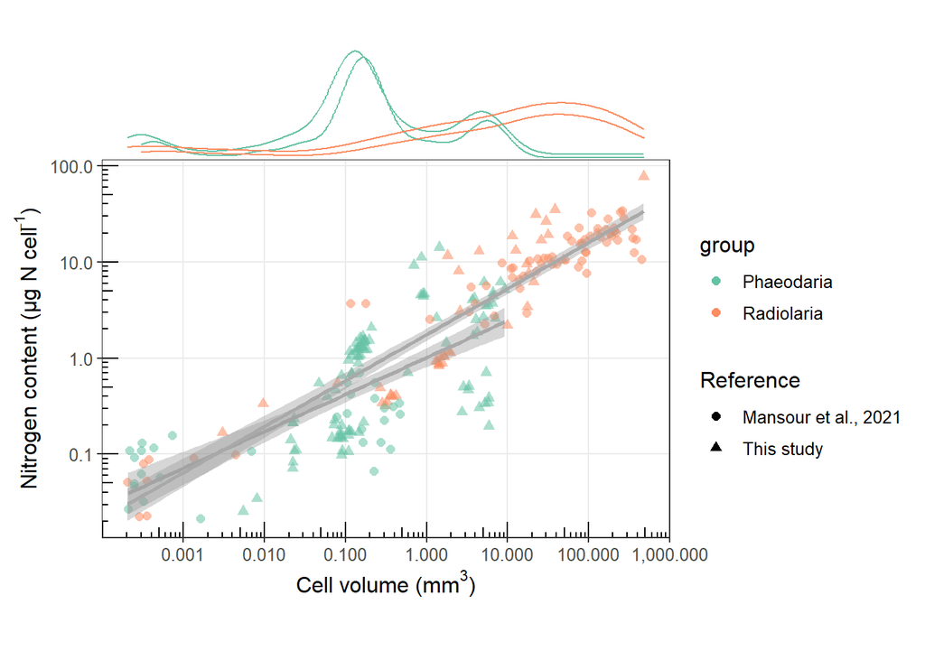

```r
# Plots

reg_carbon <- data %>%
  ggplot(., aes(x=individual_volume, y=ugC_per_ind, group=group)) +
  geom_point(aes(color = group, shape = reference, alpha =  0.9),
             size = 2) +
  scale_y_log10(breaks = 10^seq(-3,5), minor_breaks = NULL, labels = comma) +
  scale_x_log10(breaks = 10^seq(-3,5), minor_breaks = NULL, labels = comma) +
  annotation_logticks(sides="bl") +
  stat_smooth(method="lm", color="darkgrey") +
  theme_bw() +
  theme(text = element_text(size = 12), element_line(size = 0.4),
        aspect.ratio = 8/12) +
  scale_colour_discrete(name = "Group") +
  scale_color_manual(values=c("#66c2a5", "#fc8d62")) +
  scale_shape_discrete(name = "Reference") +
  guides(alpha = "none") +
  xlab(TeX("Cell volume ($mm ^3$)")) +
  ylab(TeX("Carbon content (µg C cell$^{-1}$)"))

reg_carbon <- ggMarginal(reg_carbon, type = "density",
                   margins = "x",
                   groupColour = TRUE)

reg_carbon

reg_nitrogen <- data %>%
  ggplot(., aes(x=individual_volume, y=ugN_per_ind, group=group)) +
  geom_point(aes(color = group, shape = reference, alpha =  0.9),
             size = 2) +
  scale_y_log10(breaks = 10^seq(-3,5), minor_breaks = NULL, labels = comma) +
  scale_x_log10(breaks = 10^seq(-3,5), minor_breaks = NULL, labels = comma) +
  annotation_logticks(sides="bl") +
  stat_smooth(method="lm", color="darkgrey") +
  theme_bw() +
  theme(text = element_text(size = 12), element_line(size = 0.4),
        aspect.ratio = 8/12) +
  scale_colour_discrete(name = "Group") +
  scale_color_manual(values=c("#66c2a5", "#fc8d62")) +
  scale_shape_discrete(name = "Reference") +
  guides(alpha = "none") +
  xlab(TeX("Cell volume ($mm ^3$)")) +
  ylab(TeX("Nitrogen content (µg N cell$^{-1}$)"))

reg_nitrogen <- ggMarginal(reg_nitrogen, type = "density",
                   margins = "x",
                   groupColour = TRUE)

reg_nitrogen
```

[output not shown]

```r
ggsave2("results/supp_reg_carbon.pdf", reg_carbon)
ggsave2("results/supp_reg_nitrogen.pdf", reg_nitrogen)
```

### Fig. 4a: Carbon densities

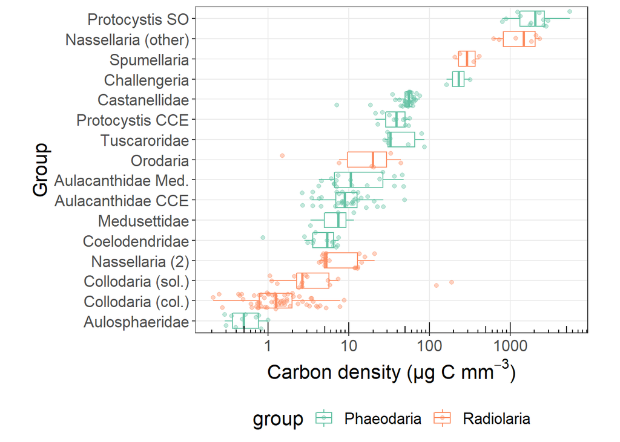

```r
# Boxplots of carbon densities arranged from lowest to highest value

p_densities <- data %>%
  mutate(type = case_when(
    type=="Oroscena" ~ "Orodaria",
    type=="Cytocladus" ~ "Orodaria",
    type=="Nassellaria (Phlebarachnium)" ~ "Nassellaria (2)",
    type=="Collodaria (Collosphaeridae)" ~ "Collodaria (col.)",
    type=="Collodaria (Sphaerozoidae)" ~ "Collodaria (col.)",
    TRUE ~ type
  )) %>%
  filter(!is.na(ugC_per_mm3)) %>%
  mutate(type_reordered = fct_reorder(type, ugC_per_mm3, .fun='median')) %>%
  ggplot(aes(ugC_per_mm3, y=type_reordered, color=group)) +
  geom_boxplot(outlier.shape = NA) +
  geom_point(position = position_jitter(seed = 42), alpha = 0.4) +
  scale_x_log10(breaks = 10^seq(-1,10), minor_breaks = NULL) +
  scale_color_discrete(name="Group") +
  scale_color_manual(values=c("#66c2a5", "#fc8d62")) +
  guides(alpha = "none", color = guide_legend(ncol=2)) +
  theme_bw() +
  theme(text = element_text(size = 16), element_line(size = 0.4),
        aspect.ratio = 10/12) +
  annotation_logticks(sides="b") +
  theme(legend.position = "bottom") +
  xlab(TeX("Carbon density (µg C mm$^{-3}$)")) +
  ylab("Group")

p_densities
```

```r
# Extracting a common legend for C and N
# Get tabular interpretation of plot
plot_table <- ggplot_gtable(ggplot_build(p_densities))
# Mark only legend in plot
legend_plot <- which(sapply(plot_table$grobs, function(x) x$name) == "guide-box")
# Extract legend
legend <- plot_table$grobs[[legend_plot]]

p_densities <- p_densities + theme(legend.position = "none")

ggsave2("results/densities_carbon.pdf", p_densities)
ggsave2("results/densities_legend.pdf", legend)

# ANOVA to test for differences between groups
aov_dens = aov(ugC_per_mm3 ~ type, data = data)
summary(aov_dens)
```

```
##              Df   Sum Sq Mean Sq F value Pr(>F)
## type         17 66328611 3901683   44.48 <2e-16 ***
## Residuals   238 20877260   87720
## ---
## Signif. codes:  0 '***' 0.001 '**' 0.01 '*' 0.05 '.' 0.1 ' ' 1
## 18 observations deleted due to missingness
```

### Fig. 4b: Nitrogen densities

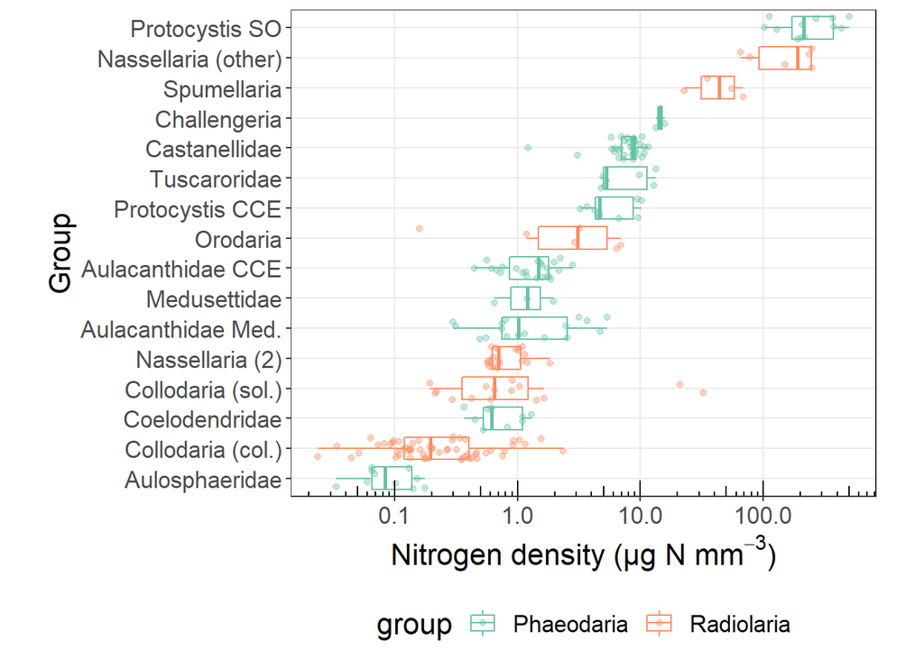

```r
# Boxplots of carbon densities arranged from lowest to highest value

p_densities <- data %>%
  mutate(type = case_when(
    type=="Oroscena" ~ "Orodaria",
    type=="Cytocladus" ~ "Orodaria",
    type=="Nassellaria (Phlebarachnium)" ~ "Nassellaria (2)",
    type=="Collodaria (Collosphaeridae)" ~ "Collodaria (col.)",
    type=="Collodaria (Sphaerozoidae)" ~ "Collodaria (col.)",
    TRUE ~ type
  )) %>%
  filter(!is.na(ugN_per_mm3)) %>%
  mutate(type_reordered = fct_reorder(type, ugN_per_mm3, .fun='median')) %>%
  ggplot(aes(ugN_per_mm3, y=type_reordered, color=group)) +
  geom_boxplot(outlier.shape = NA) +
  geom_point(position = position_jitter(seed = 42), alpha = 0.4) +
  scale_x_log10(breaks = 10^seq(-1,10), minor_breaks = NULL) +
  scale_color_discrete(name="Group") +
  scale_color_manual(values=c("#66c2a5", "#fc8d62")) +
  guides(alpha = "none", color = guide_legend(ncol=2)) +
  theme_bw() +
  theme(text = element_text(size = 16), element_line(size = 0.4),
        aspect.ratio = 10/12) +
  annotation_logticks(sides="b") +
  theme(legend.position = "bottom") +
  xlab(TeX("Nitrogen density (µg N mm$^{-3}$)")) +
  ylab("Group")

p_densities
```

```r
p_densities <- p_densities + theme(legend.position = "none")

ggsave2("results/densities_nitrogen.pdf", p_densities)

# ANOVA to test for differences between groups

aov_dens = aov(ugN_per_mm3 ~ type, data = data)
summary(aov_dens)
```

```
##              Df Sum Sq Mean Sq F value Pr(>F)
## type         17 891243   52426   49.63 <2e-16 ***
## Residuals   217 229220    1056
## ---
## Signif. codes:  0 '***' 0.001 '**' 0.01 '*' 0.05 '.' 0.1 ' ' 1
## 39 observations deleted due to missingness
```

## C:N ratio

First, we test for a correlation between carbon and nitrogen content using a Kendall’s rank correlation test.

```r
# Correlation between C and N
tab_cn <- data %>%
  filter(!is.na(ugC_per_ind)) %>%
  filter(!is.na(ugN_per_ind))

cor.test(tab_cn$ugC_per_ind, tab_cn$ugN_per_ind,
    method = "kendall")
```

```
##
##  Kendall's rank correlation tau
##
## data:  tab_cn$ugC_per_ind and tab_cn$ugN_per_ind
## z = 20.842, p-value < 2.2e-16
## alternative hypothesis: true tau is not equal to 0
## sample estimates:
##       tau
## 0.9131977
```

## Fig. 5: Boxplots C:N

```r
# ANOVA between groups

w <- data %>%
  filter(!is.na(c_n_ratio)) %>%
  filter(c_n_ratio<20) %>%
  mutate(type = case_when(
    type=="Oroscena" ~ "Orodaria",
    type=="Cytocladus" ~ "Orodaria",
    type=="Nassellaria (Phlebarachnium)" ~ "Nassellaria (2)",
    type=="Collodaria (Collosphaeridae)" ~ "Collodaria (col.)",
    type=="Collodaria (Sphaerozoidae)" ~ "Collodaria (col.)",
    TRUE ~ type
  ))

aov_cn = aov(c_n_ratio ~ type, data = w)
summary(aov_cn)
```

```
##              Df Sum Sq Mean Sq F value Pr(>F)
## type         15  772.5   51.50   12.02 <2e-16 ***
## Residuals   217  930.2    4.29
## ---
## Signif. codes:  0 '***' 0.001 '**' 0.01 '*' 0.05 '.' 0.1 ' ' 1
```

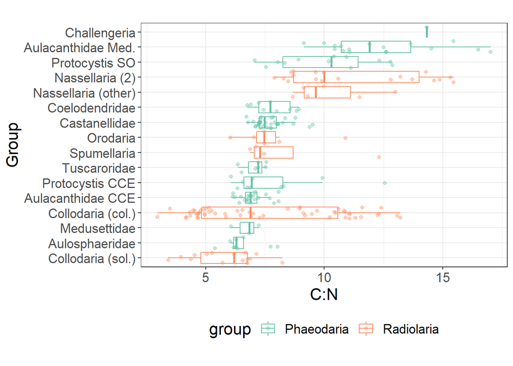

```r
# Boxplots

bp_cn <- w %>%
  mutate(type_reordered = fct_reorder(type, c_n_ratio, .fun='median')) %>%
  ggplot(., aes(c_n_ratio, y=type_reordered, color=group)) +
    geom_boxplot(outlier.shape = NA) +
    geom_point(position = position_jitter(seed = 42), alpha = 0.4) +
    scale_color_manual(values=c("#66c2a5", "#fc8d62")) +
    guides(alpha = "none", color = guide_legend(ncol=2)) +
    theme_bw() +
    theme(text = element_text(size = 16), element_line(size = 0.4),
        aspect.ratio = 8/12) +
    theme(legend.position = "bottom") +
    xlab(TeX("C:N")) +
    ylab("Group")

bp_cn
```

```r
ggsave("results/boxplots_C_N.pdf", plot = bp_cn)
```

### Fig. S6

```r
# Cross plot

z <- data %>%
  filter(type!="Cytocladus") %>%
  filter(!is.na(ugC_per_ind)) %>%
  filter(!is.na(ugN_per_ind)) %>%
  mutate(type = case_when(
    type=="Aulacanthidae CCE" ~ "Aulacanthidae",
    type=="Aulacanthidae Med." ~ "Aulacanthidae",
    type=="Protocystis SO" ~ "Challengeridae",
    type=="Protocystis CCE" ~ "Challengeridae",
    type=="Challengeria" ~ "Challengeridae",
    type=="Nassellaria (other)" ~ "Nassellaria",
    type=="Nassellaria (Phlebarachnium)" ~ "Nassellaria",
    type=="Oroscena" ~ "Orodaria",
    type=="Cytocladus" ~ "Orodaria",
    type=="Collodaria (Sphaerozoidae)" ~ "Collodaria (col.)",
    type=="Collodaria (Collosphaeridae)" ~ "Collodaria (col.)",
    TRUE ~ type
  )) %>%
  mutate(umolC_per_ind = ugC_per_ind/12) %>%
  mutate(umolN_per_ind = ugN_per_ind/14) %>%
  mutate(cn_ratio = umolC_per_ind/umolN_per_ind) %>%
  ddply(., .(type), summarise,
      meanC = mean(na.omit(umolC_per_ind)),
      meanN = mean(na.omit(umolN_per_ind)),
      sdC = sd(na.omit(umolC_per_ind)),
      sdN = sd(na.omit(umolN_per_ind)))

z
```

```
##                 type      meanC       meanN        sdC         sdN
## 1      Aulacanthidae 0.45874443 0.060258883 0.76620824 0.112677890
## 2     Aulosphaeridae 0.19114979 0.028680048 0.05893423 0.010451994
## 3      Castanellidae 0.62144428 0.081003640 0.22269764 0.029116217
## 4     Challengeridae 0.06433159 0.007011195 0.04185415 0.004360904
## 5     Coelodendridae 1.43145921 0.183027288 0.70046539 0.093710890
## 6  Collodaria (col.) 8.56876039 1.001467994 6.92700370 0.567254003
## 7  Collodaria (sol.) 4.94212952 0.987185476 2.83494583 0.750087502
## 8       Medusettidae 1.98705984 0.291267516 1.03874981 0.131764561
## 9        Nassellaria 0.41364771 0.040464309 0.24322212 0.028568069
## 10          Orodaria 3.69039211 0.516773935 2.83474751 0.382049296
## 11       Spumellaria 0.09676622 0.012367810 0.04930181 0.008102104
## 12      Tuscaroridae 3.77479498 0.537058028 1.92216025 0.285214289
```

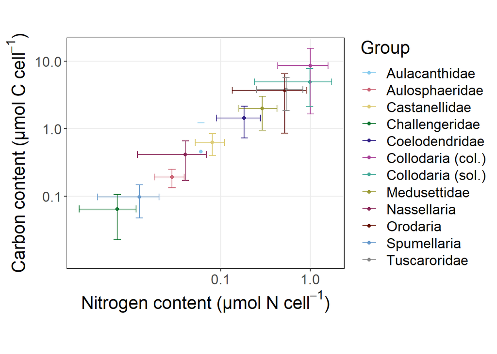

```r
p_cn <- z %>% ggplot(., aes(x = meanN, y = meanC)) +
  geom_point(aes(colour = type)) +
  geom_errorbarh(aes(xmin = meanN-sdN, xmax = meanN+sdN,
                     y = meanC, colour = type, height = 0.1)) +
  geom_errorbar(aes(ymin = meanC-sdC, ymax = meanC+sdC,
                    x = meanN, colour = type, width=0.08)) +
  scale_x_log10(breaks = 10^seq(-1,5), minor_breaks = NULL) +
  scale_y_log10(breaks = 10^seq(-1,5), minor_breaks = NULL,
                limits = c(0.012, NA)) +
  theme_bw() +
  theme(text = element_text(size = 18), element_line(size = 0.4),
        aspect.ratio = 10/12) +
  scale_color_carto_d(name = "Group", palette = "Safe") +
  xlab(TeX("Nitrogen content (µmol N cell$^{-1}$)")) +
  ylab(TeX("Carbon content (µmol C cell$^{-1}$)"))

p_cn
```

```r
ggsave2("results/supp_CN.png", plot = p_cn)
```

## Biogenic silica content and silica to carbon ratio

Reading data:

```r
# Loading silica data
data_bSi <- readxl::read_xlsx("data/data_bSi_P2107.xlsx")
bSi_lit <- readxl::read_xlsx("data/data_bSi_literature.xlsx")
data_bSi <- data_bSi %>% filter(is.na(to_remove))

# Tidying data

data_bSi <- data_bSi %>%
  mutate(nmolSi_percell = umolSi_percell*(10^3)) %>%
  mutate(ugSi_percell = umolSi_percell*67) %>%
  mutate(cell_vol_mean_mm3 = cell_vol_mean*(10^(-9))) %>%
  dplyr::select(group, type, cell_vol_mean_mm3, esd_mean, nmolSi_percell, ugSi_percell,
                reference, area)

# Get min and max values
summ_bSi <- data_bSi %>%
  group_by(type) %>%
  summarise(mean_bSi = mean(na.omit(ugSi_percell)),
            sd_bSi = sd(na.omit(ugSi_percell)))


minbSi <- summ_bSi[which.min(summ_bSi$mean_bSi),]
maxbSi <- summ_bSi[which.max(summ_bSi$mean_bSi),]
print(minbSi)
```

```
##   mean_bSi   sd_bSi
## 1 19.39424 28.64034
```

```r
print(maxbSi)
```

```
##   mean_bSi   sd_bSi
## 1 19.39424 28.64034
```

```r
bSi_lit <- bSi_lit %>%
  dplyr::select(group, type, cell_vol_mean_mm3, esd_mean, nmolSi_percell, ugSi_percell,
                reference, area)

# Merging data
all_bSi <- rbind(data_bSi, bSi_lit) %>%
  mutate(type = case_when(
    type=="Nassellaria" & area=="Med" ~ "Nassellaria (other)",
    TRUE ~ type
  ))
```

We fit a new model with our data and literature data and compare the slopes with the regression obtained by Llopis-Monferrer et al. (2020).

```r
# Computing new model
new_mod <- bind_rows(data_bSi, bSi_lit) %>%
  mutate(log_cell_vol_um3 = log10(cell_vol_mean_mm3*10^9),
         log_ugSi_percell = log10(ugSi_percell)) %>%
  lm(log_ugSi_percell ~ log_cell_vol_um3, data = .)

# Comparing the slope of this new model

slope_bsi = 0.52
coefs <- coef(summary(new_mod))

t_bsi = (coefs[2,1] - slope_bsi)/coefs[2,2]

pt(t_bsi, new_mod$df.residual)
```

```
## [1] 0.8267545
```

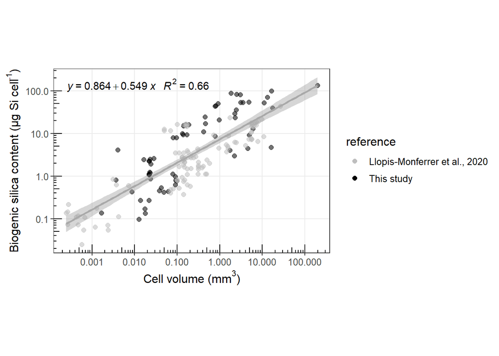

```r
# Plot

pbsi <- all_bSi %>%
  mutate(reference = case_when(
    reference=="Biard et al., 2018" ~ "Llopis-Monferrer et al., 2020",
    TRUE ~ reference)) %>%
  ggplot(., aes(x=cell_vol_mean_mm3, y=ugSi_percell)) +
  geom_point(aes(color = reference, alpha =  0.9),
             size = 2) +
  scale_y_log10(breaks = 10^seq(-3,5), minor_breaks = NULL, labels = comma) +
  scale_x_log10(breaks = 10^seq(-3,5), minor_breaks = NULL, labels = comma) +
  annotation_logticks(sides="bl") +
  stat_smooth(method="lm", color="darkgrey") +
    stat_poly_eq(formula = y~x,
               aes(label = paste(..eq.label.., ..rr.label.., sep = "~~~")),
               parse = TRUE, coef.digits = 3, f.digits = 3, p.digits = 5) +
  theme_bw() +
  theme(text = element_text(size = 12), element_line(size = 0.4),
        aspect.ratio = 8/12) +
  #scale_colour_discrete(name = "Group") +
  scale_color_manual(values=c("grey", "black")) +
  guides(alpha = "none") +
  xlab(TeX("Cell volume ($mm ^3$)")) +
  ylab(TeX("Biogenic silica content (µg Si cell$^{-1}$)"))

pbsi
```

```r
ggsave("results/supp_reg_silica.pdf", pbsi)
```

### Fig. 6: Plot Si:C

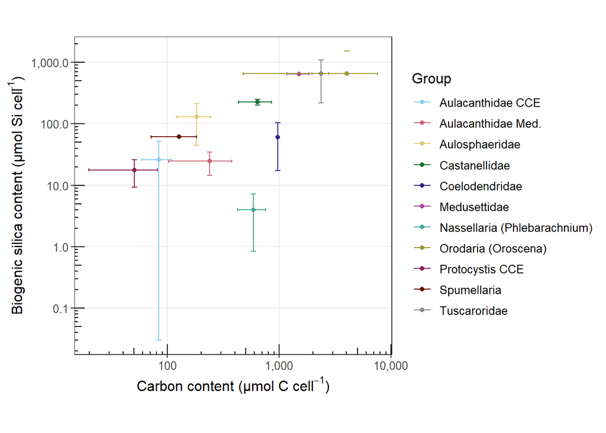

```r
# Summarizing data

# Biogenic silica
summary_silica <- all_bSi %>%
  dplyr::select(group, type, nmolSi_percell, area) %>%
  mutate(type = case_when(
    type=="Aulacanthidae" & area=="CCE" ~ "Aulacanthidae CCE",
    type=="Aulacanthidae" & area=="Med" ~ "Aulacanthidae Med.",
    type=="Protocystis" & area=="Med" ~ "Protocystis Med",
    type=="Protocystis" & area=="CCE" ~ "Protocystis CCE",
    TRUE ~ type
  )) %>%
  group_by(group, type, area) %>%
  dplyr::summarise(medSi = median(nmolSi_percell),
                   madSi = mad(na.omit(nmolSi_percell)),
                   qt1Si = quantile(na.omit(nmolSi_percell), 0.25),
                   qt3Si = quantile(na.omit(nmolSi_percell), 0.75),
  )

# Carbon
summary_carbon <- data %>% dplyr::select(group, type, ugC_per_ind, area) %>%
  mutate(nmolC_per_cell = (ugC_per_ind/12)*(10^3)) %>%
  group_by(group, type, area) %>%
  dplyr::summarise(medC = median(nmolC_per_cell),
                   madC = mad(na.omit(nmolC_per_cell)),
                   qt1C = quantile(na.omit(nmolC_per_cell), 0.25),
                   qt3C = quantile(na.omit(nmolC_per_cell), 0.75)
  )

# Merging tables

z <- inner_join(summary_carbon, summary_silica,
                by=c("group", "type", "area")) %>%
  filter(type!="Collodaria (sol.)") %>%
    mutate(type = case_when(
    type=="Oroscena" ~ "Orodaria (Oroscena)",
    TRUE ~ type
  ))


# Fig. with Median Absolute Deviation

p_sic <- ggplot(z, aes(x = medC, y = medSi)) +
  geom_point(aes(colour = type)) +
  geom_errorbar(aes(ymin = medSi-madSi, ymax = medSi+madSi,
                     x = medC, colour = type, width = 0.05)) +
  geom_errorbarh(aes(xmin = medC-madC, xmax = medC+madC,
                    y = medSi, colour = type, height = 0.05)) +
  scale_x_log10(breaks = 10^seq(-1,5), minor_breaks = NULL, labels = comma) +
  scale_y_log10(breaks = 10^seq(-1,5), minor_breaks = NULL, labels = comma) +
  annotation_logticks(sides="bl") +
  theme_bw() +
  theme(text = element_text(size = 12), element_line(size = 0.4),
        aspect.ratio = 12/12) +
  scale_color_carto_d(name = "Group", palette = "Safe") +
  xlab(TeX("Carbon content (µmol C cell$^{-1}$)")) +
  ylab(TeX("Biogenic silica content (µmol Si cell$^{-1}$)"))

p_sic
```

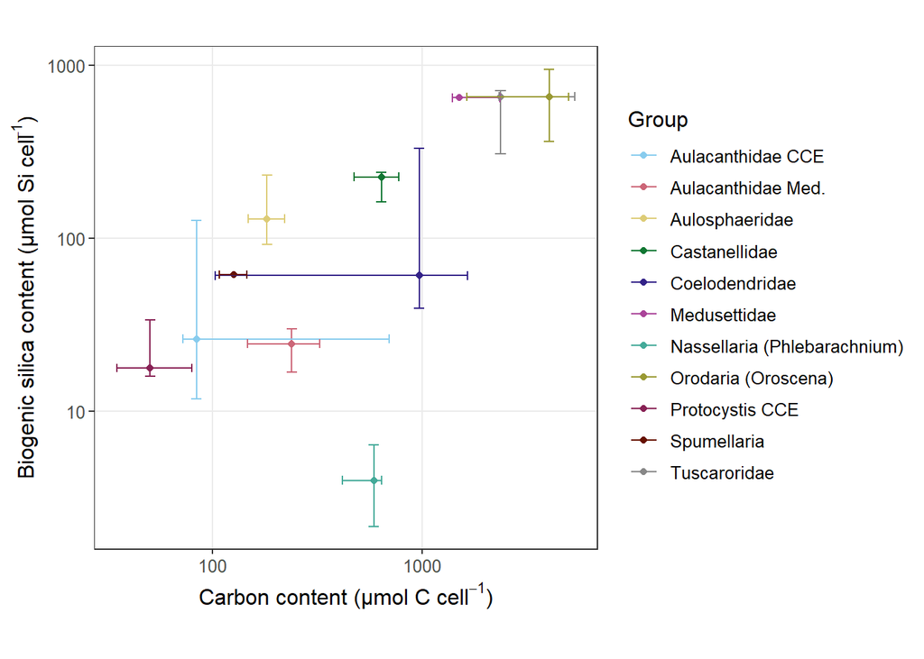

```r
ggsave("results/ratios_sic_mad.pdf", p_sic)

# Fig. with 1st and 3rd quantiles

p_sic <- ggplot(z, aes(x = medC, y = medSi)) +
  geom_point(aes(colour = type)) +
  geom_errorbar(aes(ymin = qt1Si, ymax = qt3Si,
                     x = medC, colour = type, width = 0.05)) +
  geom_errorbarh(aes(xmin = qt1C, xmax = qt3C,
                    y = medSi, colour = type, height = 0.05)) +
  scale_x_log10(breaks = 10^seq(-1,5), minor_breaks = NULL) +
  scale_y_log10(breaks = 10^seq(-1,5), minor_breaks = NULL) +
  theme_bw() +
  theme(text = element_text(size = 12), element_line(size = 0.4),
        aspect.ratio = 12/12) +
  scale_color_carto_d(name = "Group", palette = "Safe") +
  xlab(TeX("Carbon content (µmol C cell$^{-1}$)")) +
  ylab(TeX("Biogenic silica content (µmol Si cell$^{-1}$)"))

p_sic
```

```r
ggsave("results/ratios_sic_quant.pdf", p_sic)
```

### Table S5: Data summary Si & C, Si:C ratio

```r
# Biogenic silica
summary_silica <- all_bSi %>%
  dplyr::select(group, type, nmolSi_percell, area) %>%
  group_by(group, type, area) %>%
  dplyr::summarise(n_samples_si = n(),
                   median_nmolSi = as.integer(median(nmolSi_percell)),
                   min_nmolSi = as.integer(min(nmolSi_percell)),
                   max_nmolSi = as.integer(max(nmolSi_percell))
  )

# Carbon
summary_carbon <- data %>% dplyr::select(group, type, ugC_per_ind, area) %>%
    mutate(type = case_when(
    type=="Aulacanthidae CCE" ~ "Aulacanthidae",
    type=="Aulacanthidae Med." ~ "Aulacanthidae",
    type=="Protocystis SO" ~ "Protocystis",
    type=="Protocystis CCE" ~ "Protocystis",
    TRUE ~ type
  )) %>%
  mutate(nmolC_per_cell = (ugC_per_ind/12)*(10^3)) %>%
  group_by(group, type, area) %>%
  dplyr::summarise(n_samples_c = n(),
                   median_nmolC = as.integer(median(nmolC_per_cell)),
                   min_nmolC = as.integer(min(nmolC_per_cell)),
                   max_nmolC = as.integer(max(nmolC_per_cell))
  )

# Merging tables

table_ratio <- inner_join(summary_carbon, summary_silica,
                          by=c("group", "type", "area")) %>%
  filter(type!="Collodaria (sol.)") %>%
  mutate(si_c = median_nmolSi/median_nmolC)

table_ratio %>%
  kable("html",
        caption = "",
        digits = 2) %>%
  collapse_rows(.) %>%
  kable_styling("striped", full_width = F, position="left")
```

| group | type | area | n_samples_c | median_nmolC | min_nmolC | max_nmolC | n_samples_si | median_nmolSi | min_nmolSi | max_nmolSi | si_c |
| --- | --- | --- | --- | --- | --- | --- | --- | --- | --- | --- | --- |
| Phaeodaria | Aulacanthidae | CCE | 24 | 84 | 54 | 3114 | 32 | 26 | 6 | 1479 | 0.31 |
| Phaeodaria | Aulacanthidae | Med | 27 | 208 | 78 | 500 | 17 | 24 | 9 | 59 | 0.12 |
| Phaeodaria | Aulosphaeridae | CCE | 10 | 182 | 118 | 316 | 34 | 129 | 44 | 595 | 0.71 |
| Phaeodaria | Castanellidae | CCE | 35 | 640 | 112 | 1086 | 19 | 225 | 118 | 248 | 0.35 |
| Phaeodaria | Coelodendridae | CCE | 13 | 970 | 73 | 2337 | 10 | 60 | 31 | 819 | 0.06 |
| Phaeodaria | Medusettidae | CCE | 3 | 1504 | 1277 | 3179 | 1 | 648 | 648 | 648 | 0.43 |
| Phaeodaria | Protocystis | CCE | 11 | 50 | 22 | 106 | 13 | 17 | 6 | 39 | 0.34 |
| Phaeodaria | Tuscaroridae | CCE | 7 | 2367 | 2093 | 6596 | 7 | 656 | 164 | 1331 | 0.28 |
| Radiolaria | Nassellaria (Phlebarachnium) | CCE | 19 | 589 | 343 | 730 | 10 | 4 | 1 | 7 | 0.01 |
| Radiolaria | Oroscena | CCE | 5 | 4029 | 292 | 7507 | 2 | 654 | 71 | 1238 | 0.16 |
| Radiolaria | Spumellaria | CCE | 2 | 126 | 89 | 164 | 1 | 61 | 61 | 61 | 0.48 |

### Table 2: Computing excess densities

We compute the excess densities using median values of biogenic silica, carbon and nitrogen contents.

```r
# Getting median values per group and per area

# Carbon and nitrogen
median_CN <- data %>%
  dplyr::select(group, type, ugC_per_ind, ugN_per_ind, area) %>%
  mutate(type = case_when(
    type=="Aulacanthidae CCE" ~ "Aulacanthidae",
    type=="Aulacanthidae Med." ~ "Aulacanthidae",
    type=="Protocystis SO" ~ "Protocystis",
    type=="Protocystis CCE" ~ "Protocystis",
    TRUE ~ type
  )) %>%
  group_by(group, type, area) %>%
  dplyr::summarise(median_C = median(na.omit(ugC_per_ind)),
                   min_C = quantile(ugC_per_ind, 0.25, na.rm = TRUE),
                   max_C = quantile(ugC_per_ind, 0.75, na.rm = TRUE),
                   median_N = median(na.omit(ugN_per_ind)),
                   min_N = quantile(ugN_per_ind, 0.25, na.rm = TRUE),
                   max_N = quantile(ugN_per_ind, 0.75, na.rm = TRUE)
                   )

# Biogenic silica
median_si <- all_bSi %>%
  dplyr::select(group, type, ugSi_percell, area) %>%
  group_by(group, type, area) %>%
  dplyr::summarise(median_si = median(na.omit(ugSi_percell)),
                   min_si = quantile(ugSi_percell, 0.25, na.rm = TRUE),
                   max_si = quantile(ugSi_percell, 0.75, na.rm = TRUE)
                   )

# For volume, we take all data
vol1 <- data %>%
  dplyr::select(group, type, individual_volume, area) %>%
  mutate(type = case_when(
    type=="Aulacanthidae CCE" ~ "Aulacanthidae",
    type=="Aulacanthidae Med." ~ "Aulacanthidae",
    type=="Protocystis SO" ~ "Protocystis",
    type=="Protocystis CCE" ~ "Protocystis",
    TRUE ~ type
  ))

vol2 <- data_bSi %>%
  filter(type != "Nassellaria (Phlebarachnium)") %>%
  dplyr::select(group, type, cell_vol_mean_mm3, area) %>%
  mutate(individual_volume = cell_vol_mean_mm3) %>%
  dplyr::select(group, type, individual_volume, area)

median_vol <- bind_rows(vol1, vol2) %>%
  group_by(group, type, area) %>%
  dplyr::summarise(median_vol = median(na.omit(individual_volume)))

# Merging all tables
excess_densities <- inner_join(median_CN, median_si,
                               by=c("group", "type", "area")) %>%
  inner_join(., median_vol,
             by=c("group", "type", "area")) %>%
  filter(type!="Collodaria (sol.)") %>%
  mutate(rho_sw= case_when(
    area=="Med" ~ 1027.5,
    area=="CCE" ~ 1025.2,
    TRUE ~ 0
  )) %>%
  # Excess densities from median values
  mutate(MSi = median_si,
         Mom = median_C + median_N,
         VSi = median_si/2150,
         Vom = (median_C+median_N)/1050,
         Vw = median_vol - Vom - VSi,
         Mw = rho_sw*Vw,
         M = MSi + Mom + Mw,
         density = M/median_vol,
         # Excess density by subtracting sw density
         excess_density_med = density - rho_sw,
         esd_mm_med = ((3*median_vol/(4*pi))^(1/3))*2,
         esd_m = esd_mm_med*1e-3,
         speed = (1/18)*9.81*excess_density_med*(esd_m^2)/0.001,
         speed_day_med = as.integer(speed*86400)) %>%
  # Excess densities from min values
  mutate(MSi = min_si,
         Mom = min_C + min_N,
         VSi = min_si/2150,
         Vom = (min_C+min_N)/1050,
         Vw = median_vol - Vom - VSi,
         Mw = rho_sw*Vw,
         M = MSi + Mom + Mw,
         density = M/median_vol,
         # Excess density by subtracting sw density
         excess_density_min = density - rho_sw,
         esd_mm = ((3*median_vol/(4*pi))^(1/3))*2,
         esd_m = esd_mm*1e-3,
         speed = (1/18)*9.81*excess_density_min*(esd_m^2)/0.001,
         speed_day_min = as.integer(speed*86400)) %>%
  # Excess densities from max values
  mutate(MSi = max_si,
         Mom = max_C + max_N,
         VSi = max_si/2150,
         Vom = (max_C+max_N)/1050,
         Vw = median_vol - Vom - VSi,
         Mw = rho_sw*Vw,
         M = MSi + Mom + Mw,
         density = M/median_vol,
         # Excess density by subtracting sw density
         excess_density_max = density - rho_sw,
         esd_mm = ((3*median_vol/(4*pi))^(1/3))*2,
         esd_m = esd_mm*1e-3,
         speed = (1/18)*9.81*excess_density_max*(esd_m^2)/0.001,
         speed_day_max = as.integer(speed*86400)) %>%
  mutate(esd_um = as.integer(esd_mm*1e3)) %>%
  # Selecting columns
  dplyr::select(group, type, area, esd_um,
                excess_density_med, excess_density_min, excess_density_max,
                speed_day_med, speed_day_min, speed_day_max)

excess_densities %>%
    kable("html",
        caption = "",
        digits = 2) %>%
  collapse_rows(.) %>%
  kable_styling("striped", full_width = F, position="left")
```

| group | type | area | esd_um | excess_density_med | excess_density_min | excess_density_max | speed_day_med | speed_day_min | speed_day_max |
| --- | --- | --- | --- | --- | --- | --- | --- | --- | --- |
| Phaeodaria | Aulacanthidae | CCE | 593 | 8.68 | 4.02 | 42.67 | 143 | 66 | 707 |
| Phaeodaria | Aulacanthidae | Med | 679 | 5.62 | 3.83 | 6.88 | 121 | 83 | 149 |
| Phaeodaria | Aulosphaeridae | CCE | 2076 | 0.98 | 0.70 | 1.75 | 199 | 142 | 355 |
| Phaeodaria | Castanellidae | CCE | 648 | 56.95 | 40.77 | 60.60 | 1127 | 806 | 1199 |
| Phaeodaria | Coelodendridae | CCE | 1930 | 0.66 | 0.38 | 3.23 | 115 | 67 | 567 |
| Phaeodaria | Medusettidae | CCE | 2142 | 4.51 | 4.50 | 4.57 | 975 | 973 | 986 |
| Phaeodaria | Protocystis | CCE | 349 | 28.67 | 25.50 | 54.22 | 164 | 146 | 311 |
| Phaeodaria | Tuscaroridae | CCE | 1177 | 27.84 | 13.53 | 31.31 | 1817 | 883 | 2044 |
| Radiolaria | Nassellaria (Phlebarachnium) | CCE | 1368 | 0.24 | 0.15 | 0.32 | 21 | 13 | 28 |
| Radiolaria | Oroscena | CCE | 1682 | 9.75 | 5.32 | 14.00 | 1298 | 709 | 1864 |
| Radiolaria | Spumellaria | CCE | 197 | 545.03 | 543.46 | 546.59 | 1001 | 999 | 1004 |

## Biogenic silica production

```r
# Loading data
data_si32 <- readxl::read_xlsx("data/data_si32.xlsx")
si32_lit <- readxl::read_xlsx("data/data_bSi_literature.xlsx")

# Tidying data

sum(data_si32$n_cells)
```

```
## [1] 347
```

```r
data_si32 <- data_si32 %>%
  mutate(cell_vol = cell_vol_mean*10^(-9),
         nmolSi_percell = umolSi_percell*10^3) %>%
  dplyr::select(group, type, cell_vol, esd_mean, nmolSi_percell_perday,
         nmolSi_percell, Vp, reference, area)

si32_lit <- si32_lit %>%
  filter(!is.na(nmolSi_percell_perday)) %>%
  mutate(cell_vol = cell_vol_mean_mm3,
         Vp = nmolSi_percell_perday/nmolSi_percell) %>%
  dplyr::select(group, type, cell_vol, esd_mean, nmolSi_percell_perday,
         nmolSi_percell, Vp, reference, area)

# Summary of our data

si32 <- data_si32 %>%
  group_by(type) %>%
  dplyr::summarise(mean_pp = mean(na.omit(nmolSi_percell_perday)),
                   sd_pp = sd(na.omit(nmolSi_percell_perday)))
minpp <- si32[which.min(si32$mean_pp),]
maxpp <- si32[which.max(si32$mean_pp),]
print(minpp)
```

```
## # A tibble: 1 x 3
##   type        mean_pp sd_pp
##   <chr>         <dbl> <dbl>
## 1 Protocystis  0.0735    NA
```

```r
print(maxpp)
```

```
## # A tibble: 1 x 3
##   type       mean_pp sd_pp
##   <chr>        <dbl> <dbl>
## 1 Collodaria    4.31    NA
```

```r
vp <- data_si32 %>%
  group_by(type) %>%
  dplyr::summarise(mean_vp = mean(na.omit(Vp)),
                   sd_vp = sd(na.omit(Vp)))
minvp <- vp[which.min(vp$mean_vp),]
maxvp <- vp[which.max(vp$mean_vp),]
print(minvp)
```

```
## # A tibble: 1 x 3
##   type      mean_vp sd_vp
##   <chr>       <dbl> <dbl>
## 1 Orodaria 0.000653    NA
```

```r
print(maxvp)
```

```
## # A tibble: 1 x 3
##   type        mean_vp  sd_vp
##   <chr>         <dbl>  <dbl>
## 1 Nassellaria  0.0647 0.0350
```

```r
log(2)/minvp$mean_vp
```

```
## [1] 1061.452
```

```r
log(2)/maxvp$mean_vp
```

```
## [1] 10.71144
```

### Table 3

```r
# Merging tables
all_si32 <- data_si32 %>%
  bind_rows(., si32_lit)

# Summarizing table
table_si32 <- all_si32 %>%
  group_by(group, type, area, reference) %>%
  dplyr::summarise(mean_vp = mean(Vp),
                   sd_vp = sd(Vp),
                   turnover_time = as.integer(log(2)/mean_vp))

# Creating table
table_si32 %>%
  kable("html",
        caption = "",
        digits = 4) %>%
  collapse_rows(.) %>%
  kable_styling("striped", full_width = F, position="left")
```

| group | type | area | reference | mean_vp | sd_vp | turnover_time |
| --- | --- | --- | --- | --- | --- | --- |
| Phaeodaria | Aulacanthidae | CCE | This study | 0.0077 | 0.0079 | 90 |
| Phaeodaria | Aulacanthidae | Med | Llopis-Monferrer et al., 2020 | 0.0613 | 0.0887 | 11 |
| Phaeodaria | Aulosphaeridae | CCE | This study | 0.0056 | 0.0074 | 122 |
| Phaeodaria | Castanellidae | CCE | This study | 0.0007 | 0.0005 | 930 |
| Phaeodaria | Protocystis | CCE | This study | 0.0020 |  | 348 |
| Phaeodaria | Protocystis | Med | Llopis-Monferrer et al., 2020 | 0.1665 | 0.1485 | 4 |
| Radiolaria | Collodaria | CCE | This study | 0.0021 |  | 325 |
| Radiolaria | Collodaria | Med | Llopis-Monferrer et al., 2020 | 0.4216 | 0.3120 | 1 |
| Radiolaria | Nassellaria | CCE | This study | 0.0647 | 0.0350 | 10 |
| Radiolaria | Nassellaria | Med | Llopis-Monferrer et al., 2020 | 0.0856 | 0.0214 | 8 |
| Radiolaria | Orodaria | CCE | This study | 0.0007 |  | 1061 |
| Radiolaria | Spumellaria | Med | Llopis-Monferrer et al., 2020 | 0.3721 | 0.3482 | 1 |

```r
# Investigate link of uptake and Vp with size

cor.test(all_si32$nmolSi_percell_perday, all_si32$cell_vol, method="kendall")
```

```
##
##  Kendall's rank correlation tau
##
## data:  all_si32$nmolSi_percell_perday and all_si32$cell_vol
## z = 2.6718, p-value = 0.007545
## alternative hypothesis: true tau is not equal to 0
## sample estimates:
##      tau
## 0.243873
```

```r
cor.test(all_si32$Vp, all_si32$cell_vol, method="kendall")
```

```
##
##  Kendall's rank correlation tau
##
## data:  all_si32$Vp and all_si32$cell_vol
## z = -5.5088, p-value = 3.612e-08
## alternative hypothesis: true tau is not equal to 0
## sample estimates:
##        tau
## -0.5028309
```

### Table S6

```r
# Summarizing table
supp_si32 <-data_si32 %>%
  dplyr::select(group, type, esd_mean, nmolSi_percell_perday,
         nmolSi_percell, Vp) %>%
  group_by(group, type) %>%
  dplyr::summarise(n = n(),
                   mean_esd = as.integer(mean(esd_mean)),
                   sd_esd = as.integer(sd(esd_mean)),
                   mean_si_cell = round(mean(nmolSi_percell), 2),
                   sd_si_cell = round(sd(nmolSi_percell), 2),
                   mean_si_cell_day = round(mean(nmolSi_percell_perday), 2),
                   sd_si_cell_day = round(sd(nmolSi_percell_perday), 2),
                   mean_vp = round(mean(Vp), 4),
                   sd_vp = round(sd(Vp), 4),
                   turnover_time = as.integer(log(2)/mean_vp))

# Creating table
supp_si32 %>%
  kable("html",
        caption = "") %>%
  collapse_rows(.) %>%
  kable_styling("striped", full_width = F, position="left")
```

| group | type | n | mean_esd | sd_esd | mean_si_cell | sd_si_cell | mean_si_cell_day | sd_si_cell_day | mean_vp | sd_vp | turnover_time |
| --- | --- | --- | --- | --- | --- | --- | --- | --- | --- | --- | --- |
| Phaeodaria | Aulacanthidae | 4 | 832 | 558 | 142.52 | 259.73 | 0.46 | 0.70 | 0.0077 | 0.0079 | 90 |
| Phaeodaria | Aulosphaeridae | 6 | 1948 | 736 | 193.37 | 204.47 | 0.62 | 0.54 | 0.0056 | 0.0074 | 123 |
| Phaeodaria | Castanellidae | 3 | 655 | 43 | 232.95 | 7.33 | 0.17 | 0.11 | 0.0007 | 0.0005 | 990 |
| Phaeodaria | Protocystis | 1 | 353 |  | 36.95 |  | 0.07 |  | 0.0020 |  | 346 |
| Radiolaria | Collodaria | 1 | 7209 |  | 2024.30 |  | 4.31 |  | 0.0021 |  | 330 |
| Radiolaria | Nassellaria | 10 | 346 | 99 | 4.35 | 2.35 | 0.31 | 0.25 | 0.0647 | 0.0350 | 10 |
| Radiolaria | Orodaria | 1 | 1678 |  | 1238.69 |  | 0.81 |  | 0.0007 |  | 990 |

### Uptake rates and silicic acid concentration

```r
# Reading and tidying silicic acid data
data_nutrients <- readxl::read_xlsx("data/P2107_Nutrients.xlsx") %>%
  mutate(Date_GMT = as_date(Datetime_GMT)) %>%
  dplyr::select(Date_GMT, Silicic_Acid_umolperL, Actual_Depth_m)

# Mean silicic acid per day

mean_silic <- data_nutrients %>% group_by(Date_GMT) %>%
  dplyr::summarise(mean_silicic_acid = mean(Silicic_Acid_umolperL),
                   min_depth = min(na.omit(Actual_Depth_m)),
                   max_depth = max(na.omit(Actual_Depth_m)))

# Link uptake values w/ silicic acid

data_si32 <- readxl::read_xlsx("data/data_si32.xlsx")

data_si32 <- data_si32 %>%
  mutate(cell_vol = cell_vol_mean*10^(-9),
         nmolSi_percell = umolSi_percell*10^3) %>%
  dplyr::select(date, group, type, cell_vol, esd_mean, nmolSi_percell_perday,
         nmolSi_percell, Vp, reference, area) %>%
  mutate(Date_GMT = date) %>%
  left_join(., mean_silic)

# Print table
data_si32 %>%
  dplyr::select(Date_GMT, mean_silicic_acid, min_depth, max_depth) %>%
  group_by(Date_GMT) %>%
  dplyr::summarise(mean_silicic_acid = mean(mean_silicic_acid),
                   min_depth = mean(min_depth),
                   max_depth = mean(max_depth)) %>%
  kable("html",
        caption = "") %>%
  collapse_rows(.) %>%
  kable_styling("striped", full_width = F, position="left")
```

| Date_GMT | mean_silicic_acid | min_depth | max_depth |
| --- | --- | --- | --- |
| 2021-07-18 | 14.96400 | 5.495 | 80.958 |
| 2021-07-24 | 20.88050 | 3.738 | 522.860 |
| 2021-07-25 | 20.13625 | 4.832 | 519.776 |
| 2021-07-29 | 21.78250 | 5.015 | 518.891 |
| 2021-07-30 | 17.63312 | 4.737 | 519.135 |
| 2021-08-03 | 12.05937 | 4.721 | 522.432 |
| 2021-08-04 | 11.84625 | 5.311 | 519.642 |
| 2021-08-06 | 12.29625 | 5.488 | 520.188 |
| 2021-08-10 | 17.55813 | 5.392 | 204.520 |

```r
cor.test(data_si32$nmolSi_percell_perday, data_si32$mean_silicic_acid, method="kendall")
```

```
##
##  Kendall's rank correlation tau
##
## data:  data_si32$nmolSi_percell_perday and data_si32$mean_silicic_acid
## z = -0.26802, p-value = 0.7887
## alternative hypothesis: true tau is not equal to 0
## sample estimates:
##         tau
## -0.03908774
```

```r
cor.test(data_si32$Vp, data_si32$mean_silicic_acid, method="kendall")
```

```
##
##  Kendall's rank correlation tau
##
## data:  data_si32$Vp and data_si32$mean_silicic_acid
## z = -3.7969, p-value = 0.0001465
## alternative hypothesis: true tau is not equal to 0
## sample estimates:
##       tau
## -0.553743
```

### Figs for InterRad

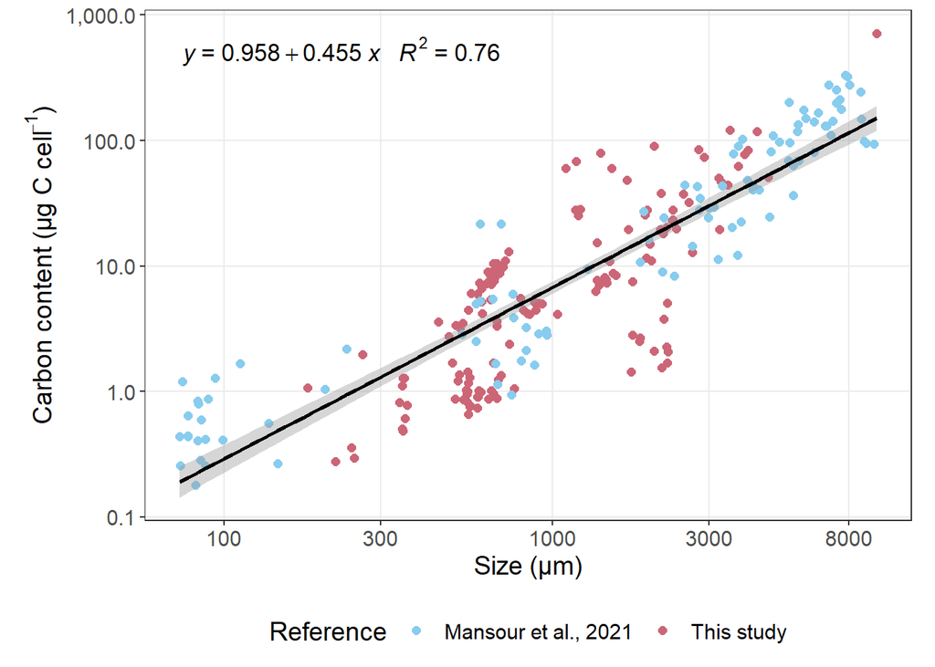

```r
esd = c(100, 300, 1000, 3000, 8000)
volumes = (((esd/1000)/2)^3)*(4/3)*pi

reg_carbon <- data %>%
  filter(type!="Acantharia") %>%
  ggplot(., aes(x=individual_volume, y=ugC_per_ind)) +
  geom_point(aes(color = reference),
             size = 2) +
  scale_y_log10(breaks = 10^seq(-3,5), minor_breaks = NULL, labels = comma) +
  scale_x_log10(breaks = volumes, minor_breaks = NULL, labels = esd) +
  geom_smooth(method = "lm", col = "black") +
  stat_poly_eq(formula = y~x,
               aes(label = paste(..eq.label.., ..rr.label.., sep = "~~~"),
                   size = 32),
               parse = TRUE, coef.digits = 3, f.digits = 3, p.digits = 5) +
  theme_bw() +
  theme(text = element_text(size = 14), element_line(size = 0.4),
        aspect.ratio = 8/12, legend.position = "bottom") +
  scale_color_carto_d(name = "Reference", palette = "Safe") +
  xlab(TeX("Size (µm)")) +
  ylab(TeX("Carbon content (µg C cell$^{-1}$)"))

reg_carbon
```

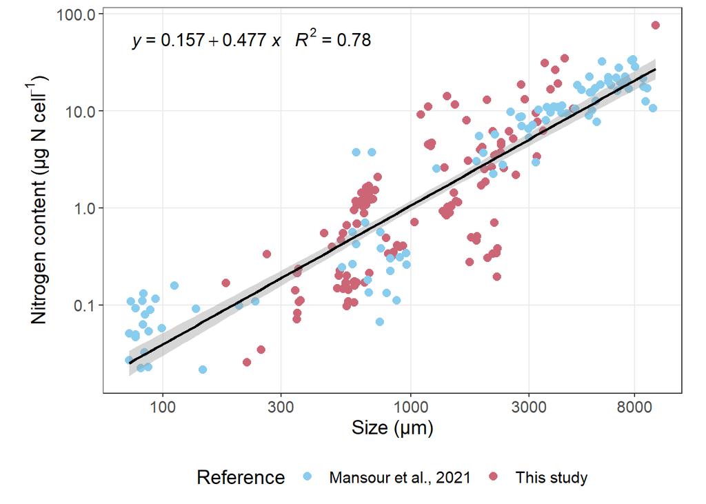

```r
reg_nitrogen <- data %>%
  filter(type!="Acantharia") %>%
  ggplot(., aes(x=individual_volume, y=ugN_per_ind)) +
  geom_point(aes(color = reference),
             size = 2.4) +
  scale_y_log10(breaks = 10^seq(-3,5), minor_breaks = NULL, labels = comma) +
  scale_x_log10(breaks = volumes, minor_breaks = NULL, labels = esd) +
  geom_smooth(method = "lm", col = "black") +
  stat_poly_eq(formula = y~x,
               aes(label = paste(..eq.label.., ..rr.label.., sep = "~~~"),
                   size = 32),
               parse = TRUE, coef.digits = 3, f.digits = 3, p.digits = 5) +
  theme_bw() +
  theme(text = element_text(size = 14), element_line(size = 0.4),
        aspect.ratio = 8/12, legend.position = "bottom") +
  scale_color_carto_d(name = "Reference", palette = "Safe") +
  xlab(TeX("Size (µm)")) +
  ylab(TeX("Nitrogen content (µg N cell$^{-1}$)"))

reg_nitrogen
```

```r
ggsave2("results/regC_for_diapo.png", plot = reg_carbon)
ggsave2("results/regN_for_diapo.png", plot = reg_nitrogen)
```

```r
data_bis <- data %>%
  dplyr::select(ugC_per_ind, individual_volume) %>%
  mutate(pgC_per_ind = ugC_per_ind*(10^6)) %>%
  mutate(vol_um3 = individual_volume*10^9)

lm(log10(pgC_per_ind) ~ log10(vol_um3), data = data_bis)
```

```
##
## Call:
## lm(formula = log10(pgC_per_ind) ~ log10(vol_um3), data = data_bis)
##
## Coefficients:
##    (Intercept)  log10(vol_um3)
##         2.8604          0.4553
```

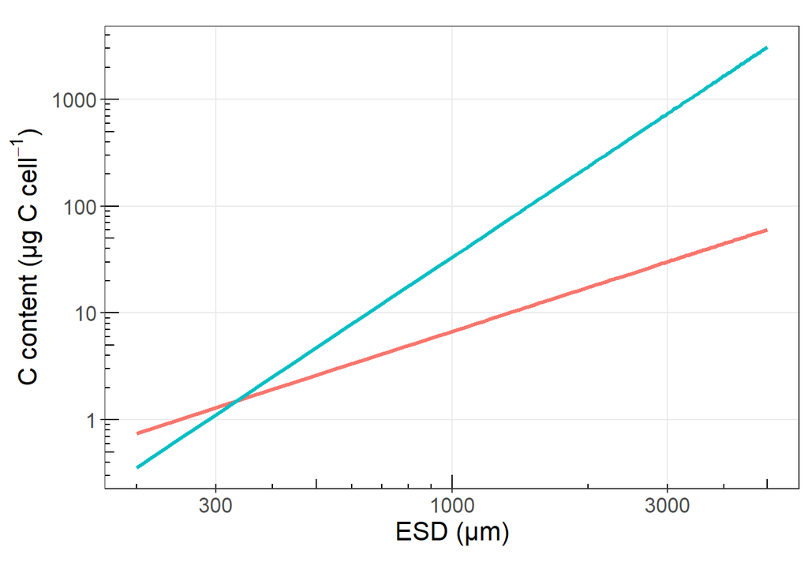

```r
x = seq(from = 200, to = 5000, length.out = 100)
xvol = (4/3)*pi*((x/2)^3)
y_diat = (0.288 * (xvol^0.811)) * (10^-6)
y_other = (0.216 * (xvol^0.939)) * (10^-6)
y_rhiz = (10^(2.86 + 0.455*log10(xvol))) * (10^-6)
dat = tibble(xvol, x, y_rhiz, y_diat, y_other)

p1 <- ggplot(dat, aes(x = x, y = y_rhiz, color = "Rhizaria")) +
  geom_line(size = 1.2) +
  geom_line(aes(x = x, y = y_other,
                color ="Various protists"), size = 1.2) +
  scale_x_log10(minor_breaks = NULL) +
  scale_y_log10(minor_breaks = NULL) +
  annotation_logticks(sides="bl") +
  theme_bw() +
  theme(text = element_text(size = 16), element_line(size = 0.4),
      aspect.ratio = 8/12, legend.position="none") +
  xlab(TeX("ESD (µm)")) +
  ylab(TeX("C content (µg C cell$^{-1}$)"))

p1
```

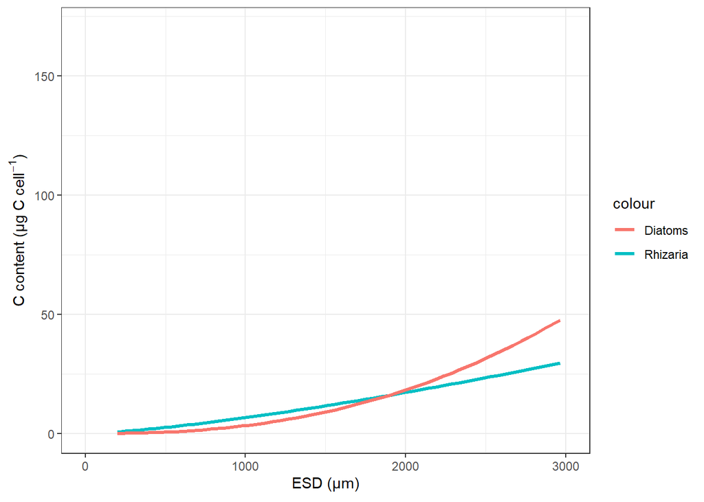

```r
p2 <- ggplot(dat, aes(x = x, y = y_rhiz, color = "Rhizaria")) +
  geom_line(size = 1.2) +
  geom_line(aes(x = x, y = y_diat,
                color ="Diatoms"),  size = 1.2) +
  xlim(c(0, 3000)) +
  theme_bw() +
  xlab(TeX("ESD (µm)")) +
  ylab(TeX("C content (µg C cell$^{-1}$)"))

p2
```

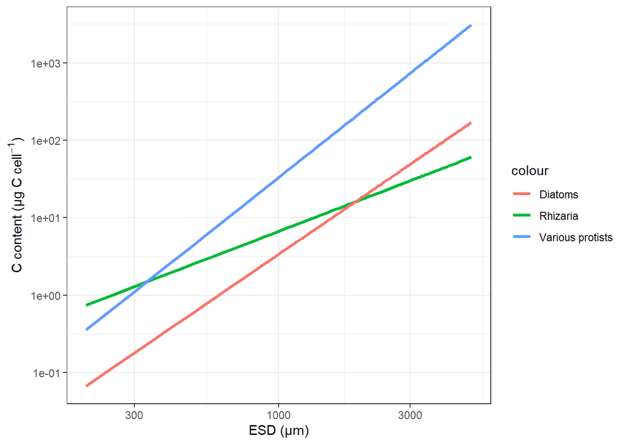

```r
p <- ggplot(dat, aes(x = x, y = y_rhiz, color = "Rhizaria")) +
  geom_line(size = 1.2) +
  geom_line(aes(x = x, y = y_diat,
                color ="Diatoms"),  size = 1.2) +
  geom_line(aes(x = x, y = y_other,
                color ="Various protists"), size = 1.2) +
  scale_x_log10() +
  scale_y_log10() +
  theme_bw() +
  xlab(TeX("ESD (µm)")) +
  ylab(TeX("C content (µg C cell$^{-1}$)"))

p
```